# Chapter 9 Faecal Microbiota Transplantation (FMT)

```r
load("data/data_27022025.Rdata")
load("data/calculations_28022025.Rdata")
```

## 9.1 What is the trend of the microbiota in each type after FMT?

### 9.1.1 Alpha diversity

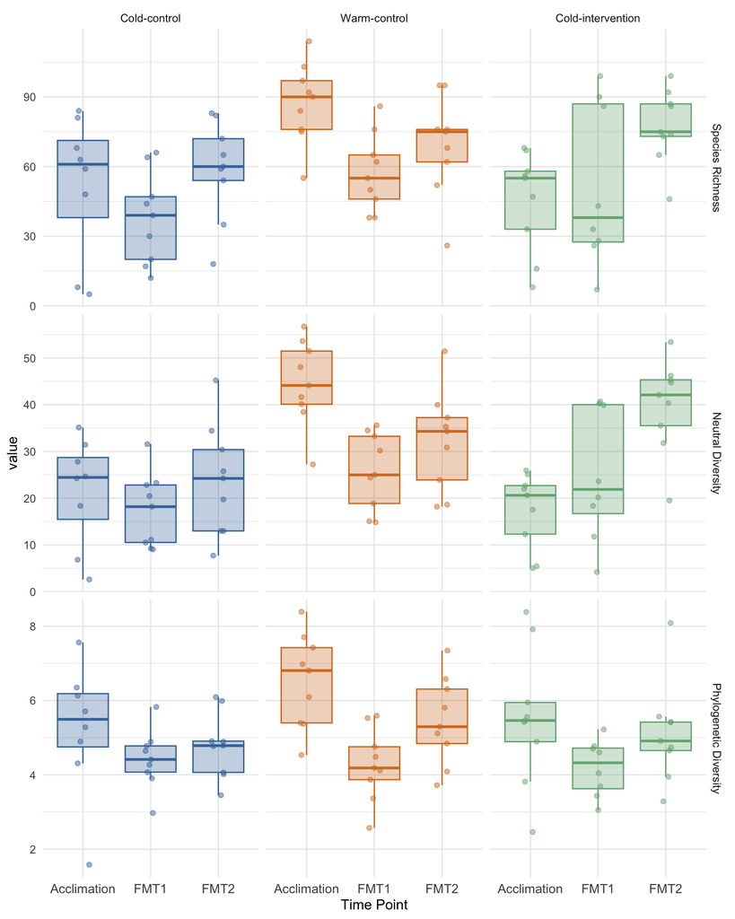

```r
label_map <- c(
  "Control" = "Cold-control",
  "Treatment" = "Cold-intervention",
  "Hot_control" = "Warm-control",
  "richness" = "Species Richness",
  "neutral" = "Neutral Diversity",
  "phylogenetic" = "Phylogenetic Diversity"
)

alpha_div %>%
  pivot_longer(-sample, names_to = "metric", values_to = "value") %>%
  left_join(., sample_metadata, by = join_by(sample == Tube_code)) %>%
  filter(time_point %in% c("FMT1","Acclimation", "FMT2")) %>%
  mutate(metric = factor(metric, levels = c("richness", "neutral", "phylogenetic"))) %>%
  ggplot(aes(y = value, x = time_point, color = type, fill = type)) +
  geom_boxplot(outlier.shape = NA, show.legend = FALSE) +
  geom_point(position = position_jitterdodge(jitter.width = 0.2, dodge.width = 0.8), alpha = 0.5, show.legend = FALSE) +
  facet_grid(metric ~ type, scales = "free_y", labeller = labeller(metric = label_map, type = label_map))+
#  facet_nested(.~metric+type, labeller = labeller(metric = label_map, type = label_map))+
  scale_color_manual(name="Type",
                       breaks=c("Control", "Hot_control", "Treatment"),
                       labels=c("Cold-Cold", "Hot-Hot", "Cold-Hot"),
                       values=c("#4477AA","#d57d2c","#76b183")) +
      scale_fill_manual(name="Type",
                       breaks=c("Control", "Hot_control", "Treatment"),
                       labels=c("Cold-Cold", "Hot-Hot", "Cold-Hot"),
                       values=c("#4477AA50","#d57d2c50","#76b18350")) +
  theme_minimal() +
  theme(axis.text.x=element_text(size=10))+
  labs(x = "Time Point", y = "value")
```

```r
alpha_div_meta <- alpha_div %>%
  left_join(sample_metadata, by = join_by(sample == Tube_code)) %>%
  filter(time_point=="FMT1"|time_point=="Acclimation"|time_point=="FMT2")
```

*Richness*

```r
Modelq0GLMMNB <- glmer.nb(richness ~ type*time_point+(1|individual), data = alpha_div_meta)
summary(Modelq0GLMMNB)
```

```
Generalized linear mixed model fit by maximum likelihood (Laplace Approximation) ['glmerMod']
 Family: Negative Binomial(5.7695)  ( log )
Formula: richness ~ type * time_point + (1 | individual)
   Data: alpha_div_meta

     AIC      BIC   logLik deviance df.resid
   757.7    783.7   -367.8    735.7       68

Scaled residuals:
     Min       1Q   Median       3Q      Max
-2.01194 -0.49654  0.06198  0.55787  1.90952

Random effects:
 Groups     Name        Variance Std.Dev.
 individual (Intercept) 0.02586  0.1608
Number of obs: 79, groups:  individual, 27

Fixed effects:
                               Estimate Std. Error z value Pr(>|z|)
(Intercept)                      3.9089     0.1696  23.046   <2e-16 ***
typeHot_control                  0.5568     0.2283   2.439   0.0147 *
typeTreatment                   -0.1233     0.2297  -0.537   0.5916
time_pointFMT1                  -0.3140     0.2167  -1.449   0.1473
time_pointFMT2                   0.1487     0.2173   0.684   0.4937
typeHot_control:time_pointFMT1  -0.1155     0.2983  -0.387   0.6987
typeTreatment:time_pointFMT1     0.4309     0.3068   1.404   0.1602
typeHot_control:time_pointFMT2  -0.3876     0.2988  -1.297   0.1945
typeTreatment:time_pointFMT2     0.4093     0.2990   1.369   0.1710
---
Signif. codes:  0 '***' 0.001 '**' 0.01 '*' 0.05 '.' 0.1 ' ' 1

Correlation of Fixed Effects:
            (Intr) typHt_ typTrt t_FMT1 t_FMT2 tH_:_FMT1 tT:_FMT1 tH_:_FMT2
typHt_cntrl -0.741
typeTretmnt -0.721  0.535
tim_pntFMT1 -0.677  0.503  0.497
tim_pntFMT2 -0.702  0.520  0.507  0.532
typH_:_FMT1  0.496 -0.671 -0.362 -0.727 -0.389
typTr:_FMT1  0.482 -0.357 -0.664 -0.707 -0.378  0.515
typH_:_FMT2  0.515 -0.684 -0.370 -0.388 -0.730  0.516     0.276
typTr:_FMT2  0.498 -0.370 -0.686 -0.384 -0.719  0.280     0.511    0.524
```

```r
emmeans::emmeans(Modelq0GLMMNB, pairwise ~ type)
```

```
$emmeans
 type        emmean     SE  df asymp.LCL asymp.UCL
 Control       3.85 0.1050 Inf      3.65      4.06
 Hot_control   4.24 0.0996 Inf      4.05      4.44
 Treatment     4.01 0.1030 Inf      3.81      4.21

Results are averaged over the levels of: time_point
Results are given on the log (not the response) scale.
Confidence level used: 0.95

$contrasts
 contrast                estimate    SE  df z.ratio p.value
 Control - Hot_control     -0.389 0.144 Inf  -2.711  0.0184
 Control - Treatment       -0.157 0.145 Inf  -1.083  0.5246
 Hot_control - Treatment    0.232 0.143 Inf   1.627  0.2342

Results are averaged over the levels of: time_point
Results are given on the log (not the response) scale.
P value adjustment: tukey method for comparing a family of 3 estimates
```

```r
emmeans::emmeans(Modelq0GLMMNB, pairwise ~ time_point)
```

```
$emmeans
 time_point  emmean     SE  df asymp.LCL asymp.UCL
 Acclimation   4.05 0.0938 Inf      3.87      4.24
 FMT1          3.84 0.0949 Inf      3.66      4.03
 FMT2          4.21 0.0895 Inf      4.03      4.38

Results are averaged over the levels of: type
Results are given on the log (not the response) scale.
Confidence level used: 0.95

$contrasts
 contrast           estimate    SE  df z.ratio p.value
 Acclimation - FMT1    0.209 0.123 Inf   1.700  0.2050
 Acclimation - FMT2   -0.156 0.121 Inf  -1.286  0.4028
 FMT1 - FMT2          -0.365 0.122 Inf  -2.997  0.0077

Results are averaged over the levels of: type
Results are given on the log (not the response) scale.
P value adjustment: tukey method for comparing a family of 3 estimates
```

*Neutral*

```r
Modelq1n <- nlme::lme(neutral ~ type*time_point,
               random = ~ 1 | individual,
               data = alpha_div_meta)
summary(Modelq1n)
```

```
Linear mixed-effects model fit by REML
  Data: alpha_div_meta
       AIC      BIC    logLik
  563.2664 587.9998 -270.6332

Random effects:
 Formula: ~1 | individual
        (Intercept) Residual
StdDev:    4.551076 9.160157

Fixed effects:  neutral ~ type * time_point
                                    Value Std.Error DF   t-value p-value
(Intercept)                     21.343055  3.603126 46  5.923483  0.0000
typeHot_control                 23.258307  4.960549 24  4.688656  0.0001
typeTreatment                   -3.944072  4.960549 24 -0.795088  0.4344
time_pointFMT1                  -3.983722  4.472618 46 -0.890691  0.3777
time_pointFMT2                   2.374489  4.472618 46  0.530895  0.5980
typeHot_control:time_pointFMT1 -14.877819  6.216964 46 -2.393101  0.0208
typeTreatment:time_pointFMT1    11.253000  6.325237 46  1.779064  0.0818
typeHot_control:time_pointFMT2 -14.775497  6.216964 46 -2.376642  0.0217
typeTreatment:time_pointFMT2    20.108022  6.216964 46  3.234380  0.0023
 Correlation:
                               (Intr) typHt_ typTrt t_FMT1 t_FMT2 tH_:_FMT1 tT:_FMT1 tH_:_FMT2
typeHot_control                -0.726
typeTreatment                  -0.726  0.528
time_pointFMT1                 -0.663  0.481  0.481
time_pointFMT2                 -0.663  0.481  0.481  0.534
typeHot_control:time_pointFMT1  0.477 -0.649 -0.346 -0.719 -0.384
typeTreatment:time_pointFMT1    0.469 -0.340 -0.638 -0.707 -0.378  0.509
typeHot_control:time_pointFMT2  0.477 -0.649 -0.346 -0.384 -0.719  0.518     0.272
typeTreatment:time_pointFMT2    0.477 -0.346 -0.649 -0.384 -0.719  0.276     0.509    0.518

Standardized Within-Group Residuals:
       Min         Q1        Med         Q3        Max
-2.1324340 -0.7088533  0.0456110  0.6569569  1.9681295

Number of Observations: 79
Number of Groups: 27
```

```r
emmeans::emmeans(Modelq1n, pairwise ~ type)
```

```
$emmeans
 type        emmean   SE df lower.CL upper.CL
 Control       20.8 2.36 26     16.0     25.7
 Hot_control   34.2 2.33 24     29.4     39.0
 Treatment     27.3 2.36 24     22.4     32.2

Results are averaged over the levels of: time_point
Degrees-of-freedom method: containment
Confidence level used: 0.95

$contrasts
 contrast                estimate   SE df t.ratio p.value
 Control - Hot_control     -13.37 3.31 24  -4.038  0.0013
 Control - Treatment        -6.51 3.33 24  -1.952  0.1461
 Hot_control - Treatment     6.86 3.31 24   2.073  0.1170

Results are averaged over the levels of: time_point
Degrees-of-freedom method: containment
P value adjustment: tukey method for comparing a family of 3 estimates
```

```r
emmeans::emmeans(Modelq1n, pairwise ~ time_point)
```

```
$emmeans
 time_point  emmean   SE df lower.CL upper.CL
 Acclimation   27.8 2.01 24     23.6     31.9
 FMT1          22.6 2.01 24     18.4     26.7
 FMT2          31.9 1.97 24     27.9     36.0

Results are averaged over the levels of: type
Degrees-of-freedom method: containment
Confidence level used: 0.95

$contrasts
 contrast           estimate   SE df t.ratio p.value
 Acclimation - FMT1     5.19 2.55 46   2.034  0.1156
 Acclimation - FMT2    -4.15 2.52 46  -1.646  0.2372
 FMT1 - FMT2           -9.34 2.52 46  -3.703  0.0016

Results are averaged over the levels of: type
Degrees-of-freedom method: containment
P value adjustment: tukey method for comparing a family of 3 estimates
```

*Phylogenetic*

```r
Model_phylo <- nlme::lme(phylogenetic ~ type*time_point,
               random = ~ 1 | individual,
               data = alpha_div_meta)
summary(Model_phylo)
```

```
Linear mixed-effects model fit by REML
  Data: alpha_div_meta
       AIC      BIC    logLik
  269.7976 294.5311 -123.8988

Random effects:
 Formula: ~1 | individual
        (Intercept) Residual
StdDev:   0.4986226 1.145917

Fixed effects:  phylogenetic ~ type * time_point
                                   Value Std.Error DF   t-value p-value
(Intercept)                     5.256251 0.4407611 46 11.925398  0.0000
typeHot_control                 1.266332 0.6064636 24  2.088060  0.0476
typeTreatment                   0.283689 0.6064636 24  0.467776  0.6442
time_pointFMT1                 -0.837008 0.5590601 46 -1.497169  0.1412
time_pointFMT2                 -0.481515 0.5590601 46 -0.861293  0.3935
typeHot_control:time_pointFMT1 -1.410952 0.7774021 46 -1.814958  0.0761
typeTreatment:time_pointFMT1   -0.545877 0.7906304 46 -0.690432  0.4934
typeHot_control:time_pointFMT2 -0.585100 0.7774021 46 -0.752635  0.4555
typeTreatment:time_pointFMT2    0.056099 0.7774021 46  0.072162  0.9428
 Correlation:
                               (Intr) typHt_ typTrt t_FMT1 t_FMT2 tH_:_FMT1 tT:_FMT1 tH_:_FMT2
typeHot_control                -0.727
typeTreatment                  -0.727  0.528
time_pointFMT1                 -0.676  0.492  0.492
time_pointFMT2                 -0.676  0.492  0.492  0.533
typeHot_control:time_pointFMT1  0.486 -0.663 -0.353 -0.719 -0.383
typeTreatment:time_pointFMT1    0.478 -0.348 -0.652 -0.707 -0.377  0.509
typeHot_control:time_pointFMT2  0.486 -0.663 -0.353 -0.383 -0.719  0.517     0.271
typeTreatment:time_pointFMT2    0.486 -0.353 -0.663 -0.383 -0.719  0.276     0.509    0.517

Standardized Within-Group Residuals:
        Min          Q1         Med          Q3         Max
-2.81722823 -0.52018811 -0.06481484  0.55835817  2.23628404

Number of Observations: 79
Number of Groups: 27
```

```r
emmeans::emmeans(Model_phylo, pairwise ~ type)
```

```
$emmeans
 type        emmean    SE df lower.CL upper.CL
 Control       4.82 0.280 26     4.24     5.39
 Hot_control   5.42 0.276 24     4.85     5.99
 Treatment     4.94 0.280 24     4.36     5.52

Results are averaged over the levels of: time_point
Degrees-of-freedom method: containment
Confidence level used: 0.95

$contrasts
 contrast                estimate    SE df t.ratio p.value
 Control - Hot_control     -0.601 0.393 24  -1.527  0.2963
 Control - Treatment       -0.120 0.396 24  -0.304  0.9505
 Hot_control - Treatment    0.481 0.393 24   1.221  0.4525

Results are averaged over the levels of: time_point
Degrees-of-freedom method: containment
P value adjustment: tukey method for comparing a family of 3 estimates
```

```r
emmeans::emmeans(Model_phylo, pairwise ~ time_point)
```

```
$emmeans
 time_point  emmean    SE df lower.CL upper.CL
 Acclimation   5.77 0.245 24     5.27     6.28
 FMT1          4.28 0.245 24     3.78     4.79
 FMT2          5.12 0.241 24     4.62     5.61

Results are averaged over the levels of: type
Degrees-of-freedom method: containment
Confidence level used: 0.95

$contrasts
 contrast           estimate    SE df t.ratio p.value
 Acclimation - FMT1    1.489 0.319 46   4.666  0.0001
 Acclimation - FMT2    0.658 0.316 46   2.085  0.1042
 FMT1 - FMT2          -0.831 0.316 46  -2.635  0.0302

Results are averaged over the levels of: type
Degrees-of-freedom method: containment
P value adjustment: tukey method for comparing a family of 3 estimates
```

#### 9.1.1.1 Beta diversity

*Number of samples used*

```r
samples_to_keep_post7 <- sample_metadata %>%
  filter(time_point=="FMT1"|time_point=="Acclimation"|time_point=="FMT2") %>%
  select(Tube_code) %>%
  pull()
subset_meta_post7 <- sample_metadata %>%
  filter(time_point=="FMT1"|time_point=="Acclimation"|time_point=="FMT2")

subset_meta_post7$time_point<-as.factor(subset_meta_post7$time_point)
subset_meta_post7$type<-as.factor(subset_meta_post7$type)
length(samples_to_keep_post7)
```

```
[1] 79
```

*Richness*

```r
richness_post7 <- as.matrix(beta_q0n$S)
richness_post7 <- as.dist(richness_post7[rownames(richness_post7) %in% samples_to_keep_post7,
               colnames(richness_post7) %in% samples_to_keep_post7])
betadisper(richness_post7, subset_meta_post7$type) %>% permutest(., pairwise = TRUE)
```

```
Permutation test for homogeneity of multivariate dispersions
Permutation: free
Number of permutations: 999

Response: Distances
          Df  Sum Sq  Mean Sq      F N.Perm Pr(>F)
Groups     2 0.06454 0.032268 4.9753    999   0.01 **
Residuals 76 0.49290 0.006485
---
Signif. codes:  0 '***' 0.001 '**' 0.01 '*' 0.05 '.' 0.1 ' ' 1

Pairwise comparisons:
(Observed p-value below diagonal, permuted p-value above diagonal)
              Control Hot_control Treatment
Control                 0.0160000     0.697
Hot_control 0.0119513                 0.002
Treatment   0.6817089   0.0035106
```

```r
adonis2(richness_post7 ~ type*time_point,
        data = subset_meta_post7 %>% arrange(match(Tube_code,labels(richness_post7))),
        permutations = 999,
        strata = subset_meta_post7 %>% arrange(match(Tube_code,labels(richness_post7))) %>% pull(individual),
        by="terms") %>%
        broom::tidy() %>%
        tt()
```

| term | df | SumOfSqs | R2 | statistic | p.value |
| --- | --- | --- | --- | --- | --- |
| type | 2 | 3.120806 | 0.11961754 | 5.546155 | 0.001 |
| time_point | 2 | 1.703776 | 0.06530413 | 3.027874 | 0.001 |
| type:time_point | 4 | 1.570884 | 0.06021051 | 1.395852 | 0.001 |
| Residual | 70 | 19.694403 | 0.75486782 | NA | NA |
| Total | 78 | 26.089870 | 1.00000000 | NA | NA |

*Neutral*

```r
neutral_post7 <- as.matrix(beta_q1n$S)
neutral_post7 <- as.dist(neutral_post7[rownames(neutral_post7) %in% samples_to_keep_post7,
               colnames(neutral_post7) %in% samples_to_keep_post7])
betadisper(neutral_post7, subset_meta_post7$type) %>% permutest(., pairwise = TRUE)
```

```
Permutation test for homogeneity of multivariate dispersions
Permutation: free
Number of permutations: 999

Response: Distances
          Df  Sum Sq  Mean Sq      F N.Perm Pr(>F)
Groups     2 0.06738 0.033689 3.8309    999  0.031 *
Residuals 76 0.66833 0.008794
---
Signif. codes:  0 '***' 0.001 '**' 0.01 '*' 0.05 '.' 0.1 ' ' 1

Pairwise comparisons:
(Observed p-value below diagonal, permuted p-value above diagonal)
              Control Hot_control Treatment
Control                 0.2150000     0.186
Hot_control 0.1985046                 0.009
Treatment   0.1611083   0.0069718
```

```r
adonis2(neutral_post7 ~ type*time_point,
        data = subset_meta_post7 %>% arrange(match(Tube_code,labels(neutral_post7))),
        permutations = 999,
        strata = subset_meta_post7 %>% arrange(match(Tube_code,labels(neutral_post7))) %>% pull(individual),
        by="terms") %>%
        broom::tidy() %>%
        tt()
```

| term | df | SumOfSqs | R2 | statistic | p.value |
| --- | --- | --- | --- | --- | --- |
| type | 2 | 3.705559 | 0.14953527 | 7.609355 | 0.001 |
| time_point | 2 | 2.217656 | 0.08949199 | 4.553951 | 0.001 |
| type:time_point | 4 | 1.813192 | 0.07317011 | 1.861693 | 0.001 |
| Residual | 70 | 17.044094 | 0.68780262 | NA | NA |
| Total | 78 | 24.780501 | 1.00000000 | NA | NA |

*Phylogenetic*

```r
phylo_post7 <- as.matrix(beta_q1p$S)
phylo_post7 <- as.dist(phylo_post7[rownames(phylo_post7) %in% samples_to_keep_post7,
               colnames(phylo_post7) %in% samples_to_keep_post7])
betadisper(phylo_post7, subset_meta_post7$type) %>% permutest(., pairwise = TRUE)
```

```
Permutation test for homogeneity of multivariate dispersions
Permutation: free
Number of permutations: 999

Response: Distances
          Df  Sum Sq  Mean Sq      F N.Perm Pr(>F)
Groups     2 0.05438 0.027192 2.1499    999  0.116
Residuals 76 0.96123 0.012648

Pairwise comparisons:
(Observed p-value below diagonal, permuted p-value above diagonal)
             Control Hot_control Treatment
Control                 0.704000     0.164
Hot_control 0.697512                 0.083
Treatment   0.155309    0.083221
```

```r
adonis2(phylo_post7 ~ type*time_point,
        data = subset_meta_post7 %>% arrange(match(Tube_code,labels(phylo_post7))),
        permutations = 999,
        strata = subset_meta_post7 %>% arrange(match(Tube_code,labels(phylo_post7))) %>% pull(individual),
          by="terms") %>%
        broom::tidy() %>%
        tt()
```

| term | df | SumOfSqs | R2 | statistic | p.value |
| --- | --- | --- | --- | --- | --- |
| type | 2 | 0.2941494 | 0.07500331 | 3.592254 | 0.001 |
| time_point | 2 | 0.5528857 | 0.14097688 | 6.752032 | 0.001 |
| type:time_point | 4 | 0.2088312 | 0.05324856 | 1.275159 | 0.147 |
| Residual | 70 | 2.8659522 | 0.73077126 | NA | NA |
| Total | 78 | 3.9218184 | 1.00000000 | NA | NA |

*dbRDA*

```r
#Richness
cca_ord <- capscale(formula = richness_post7 ~ subset_meta_post7$time_point* subset_meta_post7$type)
CAP_df <- as.data.frame(vegan::scores(cca_ord, display = "sites")) %>%
  rownames_to_column('Tube_code') %>%
  left_join(subset_meta_post7, by = 'Tube_code') %>%
  column_to_rownames('Tube_code')%>%
  mutate(x_cen = mean(CAP1, na.rm = TRUE)) %>%
  mutate(y_cen = mean(CAP2, na.rm = TRUE))

biplot_scores <- as.data.frame(vegan::scores(cca_ord, display = "bp")) %>%
  rownames_to_column("Variable")
biplot_scores$Variable <- recode(biplot_scores$Variable,
                                 "subset_meta_post7$time_pointFMT1" = "FMT1",
                                 "subset_meta_post7$time_pointFMT2"="FMT2",
                                 "subset_meta_post7$typeHot_control"="Warm-control",
                                 "subset_meta_post7$typeTreatment" = "Cold-intervention",
                                 "subset_meta_post7$time_pointFMT1:subset_meta_post7$typeHot_control"="FMT1 Warm-control",
                                 "subset_meta_post7$time_pointFMT2:subset_meta_post7$typeHot_control"="FMT2 Warm-control",
                                 "subset_meta_post7$time_pointFMT1:subset_meta_post7$typeTreatment" = "FMT1 Cold-intervention",
                                 "subset_meta_post7$time_pointFMT2:subset_meta_post7$typeTreatment" = "FMT2 Cold-intervention")

beta_richness_nmds_post7 <-CAP_df %>%
  group_by(type, time_point) %>%
  mutate(x_cen = mean(CAP1, na.rm = TRUE)) %>%
  mutate(y_cen = mean(CAP2, na.rm = TRUE)) %>%
  ungroup() %>%
  ggplot(., aes(x=CAP1,y=CAP2, color=type,shape = time_point)) +
  scale_color_manual(name="Type",
          breaks=c("Control","Hot_control", "Treatment"),
          labels=c("Cold-control","Warm-control", "Cold-intervention"),
          values=c("#4477AA","#d57d2c", "#76b183")) +
      scale_fill_manual(name="Type",
          breaks=c("Control","Hot_control", "Treatment"),
          labels=c("Cold-control","Warm-control", "Cold-intervention"),
          values=c("#4477AA50","#d57d2c50","#76b18350")) +
        scale_x_discrete(labels = c("Control" = "Cold-Cold", "Hot_control" = "Hot-Hot", "Treatment" = "Cold-Hot")) +
  geom_point(size=2) +
  geom_hline(yintercept = 0, linetype = "dotted") +
  geom_vline(xintercept = 0, linetype = "dotted") +
  geom_segment(aes(x=x_cen, y=y_cen, xend=CAP1, yend=CAP2), alpha=0.2) +
  geom_segment(data = biplot_scores, aes(x = 0, y = 0, xend = CAP1, yend = CAP2),
               inherit.aes = FALSE, arrow = arrow(length = unit(0.2, "cm")), color = "black") +
  geom_text(data = biplot_scores, aes(x = CAP1, y = CAP2, label = Variable),
            inherit.aes = FALSE, color = "black", vjust = -0.5, hjust = 0.5)+
  theme_classic()

#Neutral
cca_ord <- capscale(formula = neutral_post7 ~ subset_meta_post7$time_point* subset_meta_post7$type)
CAP_df <- as.data.frame(vegan::scores(cca_ord, display = "sites")) %>%
  rownames_to_column('Tube_code') %>%
  left_join(subset_meta_post7, by = 'Tube_code') %>%
  column_to_rownames('Tube_code')%>%
  mutate(x_cen = mean(CAP1, na.rm = TRUE)) %>%
  mutate(y_cen = mean(CAP2, na.rm = TRUE))

biplot_scores <- as.data.frame(vegan::scores(cca_ord, display = "bp")) %>%
  rownames_to_column("Variable")
biplot_scores$Variable <- recode(biplot_scores$Variable,
                                 "subset_meta_post7$time_pointFMT1" = "FMT1",
                                 "subset_meta_post7$time_pointFMT2"="FMT2",
                                 "subset_meta_post7$typeHot_control"="Warm-control",
                                 "subset_meta_post7$typeTreatment" = "Cold-intervention",
                                 "subset_meta_post7$time_pointFMT1:subset_meta_post7$typeHot_control"="FMT1 Warm-control",
                                 "subset_meta_post7$time_pointFMT2:subset_meta_post7$typeHot_control"="FMT2 Warm-control",
                                 "subset_meta_post7$time_pointFMT1:subset_meta_post7$typeTreatment" = "FMT1 Cold-intervention",
                                 "subset_meta_post7$time_pointFMT2:subset_meta_post7$typeTreatment" = "FMT2 Cold-intervention")

beta_neutral_nmds_post7 <- CAP_df %>%
  group_by(type, time_point) %>%
  mutate(x_cen = mean(CAP1, na.rm = TRUE)) %>%
  mutate(y_cen = mean(CAP2, na.rm = TRUE)) %>%
  ungroup() %>%
  ggplot(., aes(x=CAP1,y=CAP2, color=type,shape = time_point)) +
  scale_color_manual(name="Type",
          breaks=c("Control","Hot_control", "Treatment"),
          labels=c("Cold-control","Warm-control", "Cold-intervention"),
          values=c("#4477AA","#d57d2c", "#76b183")) +
      scale_fill_manual(name="Type",
          breaks=c("Control","Hot_control", "Treatment"),
          labels=c("Cold-control","Warm-control", "Cold-intervention"),
          values=c("#4477AA50","#d57d2c50","#76b18350")) +
        scale_x_discrete(labels = c("Control" = "Cold-Cold", "Hot_control" = "Hot-Hot", "Treatment" = "Cold-Hot")) +
  geom_point(size=2) +
  geom_hline(yintercept = 0, linetype = "dotted") +
  geom_vline(xintercept = 0, linetype = "dotted") +
  geom_segment(aes(x=x_cen, y=y_cen, xend=CAP1, yend=CAP2), alpha=0.2) +
  geom_segment(data = biplot_scores, aes(x = 0, y = 0, xend = CAP1, yend = CAP2),
               inherit.aes = FALSE, arrow = arrow(length = unit(0.2, "cm")), color = "black") +
  geom_text(data = biplot_scores, aes(x = CAP1, y = CAP2, label = Variable),
            inherit.aes = FALSE, color = "black", vjust = -0.5, hjust = 0.5)+
  theme_classic()


#Phylogenetic
cca_ord <- capscale(formula = phylo_post7 ~ subset_meta_post7$time_point* subset_meta_post7$type)
CAP_df <- as.data.frame(vegan::scores(cca_ord, display = "sites")) %>%
  rownames_to_column('Tube_code') %>%
  left_join(subset_meta_post7, by = 'Tube_code') %>%
  column_to_rownames('Tube_code')%>%
  mutate(x_cen = mean(CAP1, na.rm = TRUE)) %>%
  mutate(y_cen = mean(CAP2, na.rm = TRUE))

biplot_scores <- as.data.frame(vegan::scores(cca_ord, display = "bp")) %>%
  rownames_to_column("Variable")
biplot_scores$Variable <- recode(biplot_scores$Variable,
                                 "subset_meta_post7$time_pointFMT1" = "FMT1",
                                 "subset_meta_post7$time_pointFMT2"="FMT2",
                                 "subset_meta_post7$typeHot_control"="Warm-control",
                                 "subset_meta_post7$typeTreatment" = "Cold-intervention",
                                 "subset_meta_post7$time_pointFMT1:subset_meta_post7$typeHot_control"="FMT1 Warm-control",
                                 "subset_meta_post7$time_pointFMT2:subset_meta_post7$typeHot_control"="FMT2 Warm-control",
                                 "subset_meta_post7$time_pointFMT1:subset_meta_post7$typeTreatment" = "FMT1 Cold-intervention",
                                 "subset_meta_post7$time_pointFMT2:subset_meta_post7$typeTreatment" = "FMT2 Cold-intervention")

beta_phylogenetic_nmds_post7 <- CAP_df %>%
  group_by(type, time_point) %>%
  mutate(x_cen = mean(CAP1, na.rm = TRUE)) %>%
  mutate(y_cen = mean(CAP2, na.rm = TRUE)) %>%
  ungroup() %>%
  ggplot(., aes(x=CAP1,y=CAP2, color=type,shape = time_point)) +
  scale_color_manual(name="Type",
          breaks=c("Control","Hot_control", "Treatment"),
          labels=c("Cold-control","Warm-control", "Cold-intervention"),
          values=c("#4477AA","#d57d2c", "#76b183")) +
      scale_fill_manual(name="Type",
          breaks=c("Control","Hot_control", "Treatment"),
          labels=c("Cold-control","Warm-control", "Cold-intervention"),
          values=c("#4477AA50","#d57d2c50","#76b18350")) +
        scale_x_discrete(labels = c("Control" = "Cold-Cold", "Hot_control" = "Hot-Hot", "Treatment" = "Cold-Hot")) +
  geom_point(size=2) +
  geom_hline(yintercept = 0, linetype = "dotted") +
  geom_vline(xintercept = 0, linetype = "dotted") +
  geom_segment(aes(x=x_cen, y=y_cen, xend=CAP1, yend=CAP2), alpha=0.2) +
  geom_segment(data = biplot_scores, aes(x = 0, y = 0, xend = CAP1, yend = CAP2),
               inherit.aes = FALSE, arrow = arrow(length = unit(0.2, "cm")), color = "black") +
  geom_text(data = biplot_scores, aes(x = CAP1, y = CAP2, label = Variable),
            inherit.aes = FALSE, color = "black", vjust = -0.5, hjust = 0.5)+
  theme_classic()
```

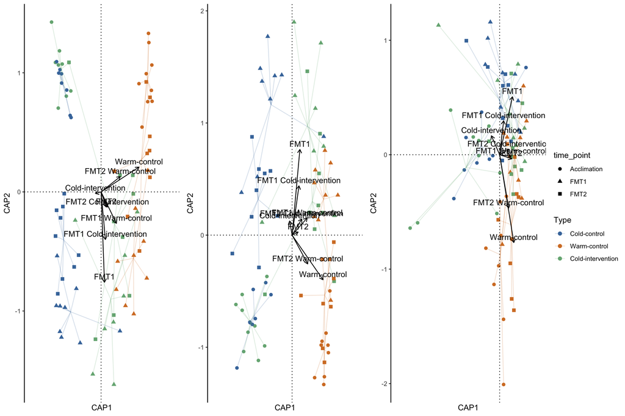

```r
ggarrange(beta_richness_nmds_post7, beta_neutral_nmds_post7, beta_phylogenetic_nmds_post7, ncol=3, nrow=1, common.legend = TRUE, legend="right")
```

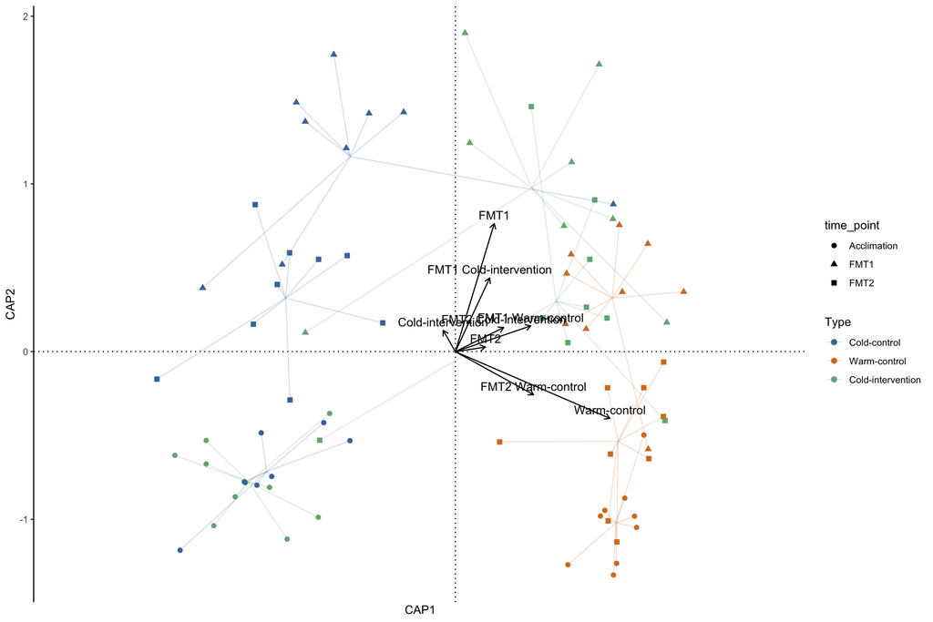

```r
beta_neutral_nmds_post7
```

## 9.2 Differences between acclimation and FMT1 across the three experimental groups

### 9.2.1 Functional differences

*CI from acclimation to FMT1*

```r
significant_element<-element_gift %>%
  filter(time_point %in% c("FMT1","Acclimation") & type == "Treatment") %>%
  select(-time_point, -type) %>%
  filter(rowSums(across(where(is.numeric), ~ . != 0)) > 0) %>%
  select(Tube_code, where( ~ is.numeric(.) && sum(.) > 0)) %>%
  left_join(sample_metadata[c(1, 10)], by = "Tube_code") %>%
  pivot_longer(-c(Tube_code, time_point),
               names_to = "trait",
               values_to = "value") %>%
  group_by(trait) %>%
  summarise(p_value = wilcox.test(value ~ time_point)$p.value) %>%
  mutate(p_adjust = p.adjust(p_value, method = "BH")) %>%
  filter(p_adjust < 0.05) %>%
  remove_rownames() %>%
  left_join(., uniqueGIFT_db, by=join_by("trait"=="Code_element"))
```

```r
element_gift_sig <- element_gift %>%
  select(Tube_code, all_of(intersect(
    significant_element$trait,
    colnames(element_gift)
  ))) %>%
  left_join(., sample_metadata[c(1, 7, 10)], by = join_by(Tube_code == Tube_code)) %>%
  filter(time_point %in% c("FMT1","Acclimation"))%>%
  filter(type=="Treatment")

difference_table <- element_gift_sig %>%
  select(-Tube_code, -type) %>%
  group_by(time_point) %>%
  summarise(across(everything(), mean)) %>%
  t() %>%
  row_to_names(row_number = 1) %>%
  as.data.frame() %>%
  mutate_if(is.character, as.numeric) %>%
  rownames_to_column(., "Elements") %>%
  left_join(.,uniqueGIFT_db[c(1,3,4)],by = join_by(Elements == Code_element)) %>%
  arrange(Function) %>%
  mutate(Difference=Acclimation-FMT1)%>%
  mutate(group_color = ifelse(Difference <0,"FMT1", "Acclimation"))
```

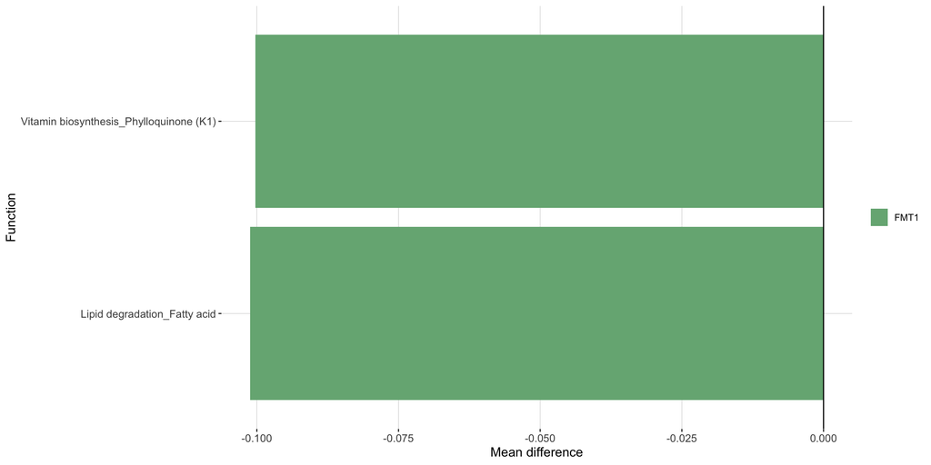

```r
difference_table %>%
  ggplot(aes(x=forcats::fct_reorder(Function,Difference), y=Difference, fill=group_color)) +
  geom_col() +
  scale_fill_manual(values=c("#76b183",'#008080')) +
  geom_hline(yintercept=0) +
  coord_flip()+
  theme(axis.text = element_text(size = 10),
        axis.title = element_text(size = 12),
        legend.position = "right",
        legend.title = element_blank(),
        panel.background = element_blank(),
        panel.grid.major = element_line(size = 0.15, linetype = 'solid',
                                        colour = "grey"))+
  xlab("Function") +
  ylab("Mean difference")
```

*CC from acclimation to FMT1*

```r
significant_element<-element_gift %>%
  filter(time_point %in% c("FMT1","Acclimation") & type == "Control") %>%
  select(-time_point, -type) %>%
  filter(rowSums(across(where(is.numeric), ~ . != 0)) > 0) %>%
  select(Tube_code, where( ~ is.numeric(.) && sum(.) > 0)) %>%
  left_join(sample_metadata[c(1, 10)], by = "Tube_code") %>%
  pivot_longer(-c(Tube_code, time_point),
               names_to = "trait",
               values_to = "value") %>%
  group_by(trait) %>%
  summarise(p_value = wilcox.test(value ~ time_point)$p.value) %>%
  mutate(p_adjust = p.adjust(p_value, method = "BH")) %>%
  filter(p_adjust < 0.05) %>%
  remove_rownames() %>%
  left_join(., uniqueGIFT_db, by=join_by("trait"=="Code_element"))
```

```r
element_gift_sig <- element_gift %>%
  select(Tube_code, all_of(intersect(
    significant_element$trait,
    colnames(element_gift)
  ))) %>%
  left_join(., sample_metadata[c(1, 7, 10)], by = join_by(Tube_code == Tube_code)) %>%
  filter(time_point %in% c("FMT1","Acclimation"))%>%
  filter(type=="Control")

difference_table <- element_gift_sig %>%
  select(-Tube_code, -type) %>%
  group_by(time_point) %>%
  summarise(across(everything(), mean)) %>%
  t() %>%
  row_to_names(row_number = 1) %>%
  as.data.frame() %>%
  mutate_if(is.character, as.numeric) %>%
  rownames_to_column(., "Elements") %>%
  left_join(.,uniqueGIFT_db[c(1,3,4)],by = join_by(Elements == Code_element)) %>%
  arrange(Function) %>%
  mutate(Difference=Acclimation-FMT1)%>%
  mutate(group_color = ifelse(Difference <0,"FMT1", "Acclimation"))
```

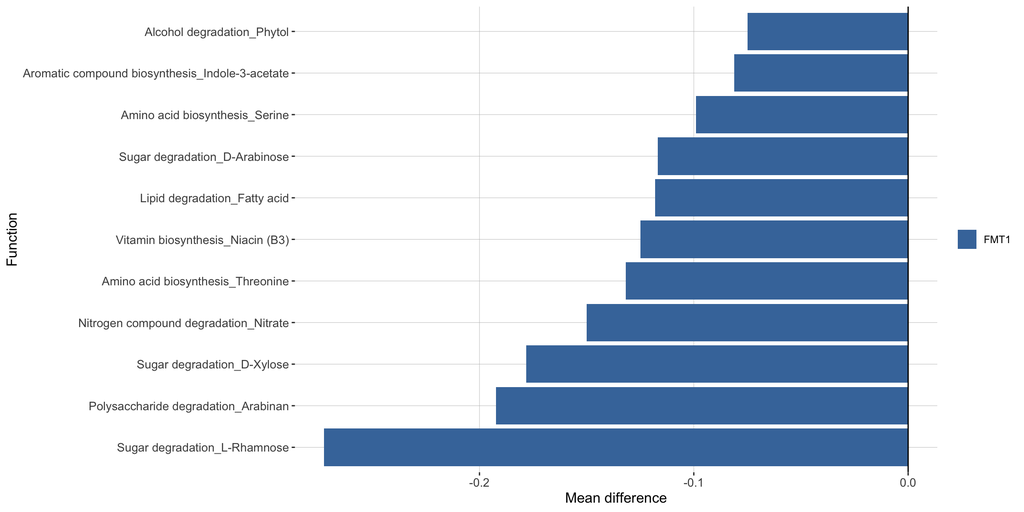

```r
difference_table %>%
  ggplot(aes(x=forcats::fct_reorder(Function,Difference), y=Difference, fill=group_color)) +
  geom_col() +
  scale_fill_manual(values=c("#4477AA",'#008080')) +
  geom_hline(yintercept=0) +
  coord_flip()+
  theme(axis.text = element_text(size = 10),
        axis.title = element_text(size = 12),
        legend.position = "right",
        legend.title = element_blank(),
        panel.background = element_blank(),
        panel.grid.major = element_line(size = 0.15, linetype = 'solid',
                                        colour = "grey"))+
  xlab("Function") +
  ylab("Mean difference")
```

*WC from acclimation to FMT1*

```r
element_gift %>%
  filter(time_point %in% c("FMT1","Acclimation") & type == "Hot_control") %>%
  select(-time_point, -type) %>%
  filter(rowSums(across(where(is.numeric), ~ . != 0)) > 0) %>%
  select(Tube_code, where( ~ is.numeric(.) && sum(.) > 0)) %>%
  left_join(sample_metadata[c(1, 10)], by = "Tube_code") %>%
  pivot_longer(-c(Tube_code, time_point),
               names_to = "trait",
               values_to = "value") %>%
  group_by(trait) %>%
  summarise(p_value = wilcox.test(value ~ time_point)$p.value) %>%
  mutate(p_adjust = p.adjust(p_value, method = "BH")) %>%
  filter(p_adjust < 0.05) %>%
  remove_rownames() %>%
  left_join(., uniqueGIFT_db, by=join_by("trait"=="Code_element"))
```

```
# A tibble: 0 × 6
# ℹ 6 variables: trait <chr>, p_value <dbl>, p_adjust <dbl>, Domain <chr>, Function <chr>, Element <chr>
```

### 9.2.2 Differential abundances

#### 9.2.2.1 CI: acclimation vs FMT1

*Structural zeros*

```r
struc <- structural_zeros %>%
  filter(present=="Acclimation")%>%
  count(phylum, name = "Acclimation") %>%
  arrange(desc(Acclimation))
structural_zeros %>%
  filter(present=="FMT1")%>%
  count(phylum, name = "FMT1") %>%
  arrange(desc(FMT1)) %>%
  full_join(., struc, by="phylum") %>%
  mutate(across(everything(), ~ ifelse(is.na(.), 0, .))) %>%
  tt()
```

| phylum | FMT1 | Acclimation |
| --- | --- | --- |
| p__Bacteroidota | 33 | 11 |
| p__Bacillota_A | 25 | 16 |
| p__Pseudomonadota | 5 | 8 |
| p__Desulfobacterota | 4 | 2 |
| p__Bacillota | 3 | 9 |
| p__Campylobacterota | 2 | 0 |
| p__Cyanobacteriota | 2 | 2 |
| p__Bacillota_C | 1 | 1 |
| p__Elusimicrobiota | 1 | 0 |
| p__Verrucomicrobiota | 0 | 2 |
| p__Actinomycetota | 0 | 1 |
| p__Bacillota_B | 0 | 1 |

```r
phylo_samples <- sample_metadata %>%
  filter(type == "Treatment" & time_point %in% c("Acclimation", "FMT1") )%>%
  column_to_rownames("Tube_code") %>%
  sample_data()
phylo_genome <- genome_counts_filt %>%
  filter(!genome %in% structural_zeros$genome) %>%
  select(one_of(c("genome",rownames(phylo_samples)))) %>%
  filter(rowSums(across(where(is.numeric), ~ . != 0)) > 0) %>%
  select(genome, where(~ is.numeric(.) && sum(.) > 0)) %>%
  column_to_rownames("genome") %>%
  otu_table(., taxa_are_rows = TRUE)
phylo_taxonomy <- genome_metadata %>%
  filter(genome %in% rownames(phylo_genome)) %>%
  column_to_rownames("genome") %>%
  dplyr::select(domain,phylum,class,order,family,genus,species) %>%
  as.matrix() %>%
  tax_table()

physeq_genome_filtered <- phyloseq(phylo_genome, phylo_taxonomy, phylo_samples)
```

```r
ancom_rand_output_ci_accli_fmt1 = ancombc2(data = physeq_genome_filtered,
                  assay_name = "counts",
                  tax_level = NULL,
                  fix_formula = "time_point",
                  p_adj_method = "holm",
                  pseudo_sens = TRUE,
                  prv_cut =0,
                  lib_cut = 0,
                  s0_perc = 0.05,
                  group = NULL,
                  struc_zero = FALSE,
                  neg_lb = FALSE,
                  alpha = 0.05,
                  n_cl = 2,
                  verbose = TRUE,
                  global = FALSE,
                  pairwise = FALSE,
                  dunnet = FALSE,
                  trend = FALSE,
                  iter_control = list(tol = 1e-5, max_iter = 20, verbose = FALSE),
                  em_control = list(tol = 1e-5, max_iter = 100),
                  mdfdr_control = list(fwer_ctrl_method = "holm", B = 100),
                  trend_control = NULL)
```

```r
save(ancom_rand_output_ci_accli_fmt1, file="data/ancom_rand_output_ci_accli_fmt1.RData")
```

```r
load("data/ancom_rand_output_ci_accli_fmt1.RData")
```

```r
ancom_rand_output_ci_accli_fmt1$res %>%
  dplyr::select(taxon, lfc_time_pointFMT1, p_time_pointFMT1) %>%
  filter(p_time_pointFMT1 < 0.05) %>%
  left_join(., genome_metadata, by=join_by("taxon"=="genome")) %>%
  select(2,3,7,8,9) %>%
  tt()
```

| lfc_time_pointFMT1 | p_time_pointFMT1 | order | family | genus |
| --- | --- | --- | --- | --- |
| -1.8462367 | 0.0286090261 | o__Bacteroidales | f__Rikenellaceae | g__Alistipes |
| -1.0602262 | 0.0256488405 | o__Campylobacterales | f__Helicobacteraceae | g__Helicobacter_J |
| -2.1031126 | 0.0039988943 | o__Mycoplasmatales | f__Mycoplasmoidaceae | g__Mycoplasmoides |
| -1.1937360 | 0.0258952249 | o__Lachnospirales | f__Lachnospiraceae | g__Hungatella_A |
| 1.1869122 | 0.0246642650 | o__Oscillospirales | f__Ruminococcaceae | g__Negativibacillus |
| -3.0923830 | 0.0007999100 | o__Erysipelotrichales | f__Coprobacillaceae | g__Coprobacillus |
| -1.2524541 | 0.0482834029 | o__Opitutales | f__LL51 | g__ |
| -1.2157647 | 0.0209074696 | o__Bacteroidales | f__Bacteroidaceae | g__Bacteroides |
| -2.1668443 | 0.0092167448 | o__Gastranaerophilales | f__Gastranaerophilaceae | g__Scatousia |
| 1.8856206 | 0.0022558153 | o__Lachnospirales | f__Lachnospiraceae | g__ |
| -1.2811877 | 0.0290779856 | o__Bacteroidales | f__Marinifilaceae | g__Odoribacter |
| -0.9960276 | 0.0294171519 | o__Selenomonadales | f__ | g__ |
| -1.9064058 | 0.0121488844 | o__Lachnospirales | f__Lachnospiraceae | g__CAG-95 |
| -2.0548675 | 0.0169404933 | o__Christensenellales | f__ | g__ |
| -1.8189515 | 0.0001244128 | o__Bacteroidales | f__Marinifilaceae | g__Odoribacter |
| 1.0549620 | 0.0254528501 | o__Erysipelotrichales | f__Erysipelotrichaceae | g__Clostridium_AQ |
| -1.4937622 | 0.0113515485 | o__Bacteroidales | f__Tannerellaceae | g__Parabacteroides_B |
| 1.9263692 | 0.0019001955 | o__Bacteroidales | f__Tannerellaceae | g__Parabacteroides |

```r
taxonomy <- data.frame(physeq_genome_filtered@tax_table) %>%
  rownames_to_column(., "taxon") %>%
  mutate_at(vars(order, phylum, family, genus, species), ~ str_replace(., "[dpcofgs]__", ""))

ancombc_rand_table_mag <- ancom_rand_output_ci_accli_fmt1$res %>%
  dplyr::select(taxon, lfc_time_pointFMT1, p_time_pointFMT1) %>%
  #filter(p_time_pointFMT1 < 0.05) %>%
  dplyr::arrange(p_time_pointFMT1) %>%
  merge(., taxonomy, by="taxon") %>%
  mutate_at(vars(phylum, species), ~ str_replace(., "[dpcofgs]__", ""))%>%
  dplyr::arrange(lfc_time_pointFMT1)

ancombc_rand_table_mag
```

```
                   taxon lfc_time_pointFMT1 p_time_pointFMT1      domain            phylum                  class                order               family                genus                      species
1  AH1_2nd_18:bin_000011       -3.092382977     0.0007999100 d__Bacteria         Bacillota             c__Bacilli   Erysipelotrichales     Coprobacillaceae        Coprobacillus
2   AH1_2nd_2:bin_000003       -2.648161454     1.0000000000 d__Bacteria       Bacillota_A          c__Clostridia       Lachnospirales      Lachnospiraceae             JAAYNV01
3   AH1_2nd_1:bin_000003       -2.166844294     0.0092167448 d__Bacteria   Cyanobacteriota    c__Vampirovibrionia  Gastranaerophilales Gastranaerophilaceae            Scatousia
4  AH1_2nd_12:bin_000041       -2.103112630     0.0039988943 d__Bacteria         Bacillota             c__Bacilli      Mycoplasmatales    Mycoplasmoidaceae       Mycoplasmoides
5   LI1_2nd_4:bin_000001       -2.054867498     0.0169404933 d__Bacteria       Bacillota_A          c__Clostridia   Christensenellales
6   AH1_2nd_8:bin_000006       -1.906405809     0.0121488844 d__Bacteria       Bacillota_A          c__Clostridia       Lachnospirales      Lachnospiraceae               CAG-95
7  AH1_2nd_10:bin_000041       -1.846236702     0.0286090261 d__Bacteria      Bacteroidota         c__Bacteroidia        Bacteroidales        Rikenellaceae            Alistipes
8   LI1_2nd_4:bin_000026       -1.818951547     0.0001244128 d__Bacteria      Bacteroidota         c__Bacteroidia        Bacteroidales       Marinifilaceae          Odoribacter
9  AH1_2nd_10:bin_000040       -1.684889357     1.0000000000 d__Bacteria       Bacillota_A          c__Clostridia      Oscillospirales      Ruminococcaceae               UBA866
10 AH1_2nd_19:bin_000011       -1.494726874     0.0611399521 d__Bacteria  Desulfobacterota    c__Desulfovibrionia   Desulfovibrionales  Desulfovibrionaceae            Mailhella
11  LI1_2nd_7:bin_000042       -1.493762171     0.0113515485 d__Bacteria      Bacteroidota         c__Bacteroidia        Bacteroidales       Tannerellaceae    Parabacteroides_B
12 AH1_2nd_19:bin_000072       -1.478268874     1.0000000000 d__Bacteria       Bacillota_A          c__Clostridia       Lachnospirales      Lachnospiraceae
13 AH1_2nd_14:bin_000015       -1.316753957     0.1424337358 d__Bacteria       Bacillota_A          c__Clostridia   Christensenellales              UBA3700
14  AH1_2nd_1:bin_000039       -1.281187716     0.0290779856 d__Bacteria      Bacteroidota         c__Bacteroidia        Bacteroidales       Marinifilaceae          Odoribacter
```

[output cut: 76 more lines]

```r
colors_alphabetic <- read_tsv("https://raw.githubusercontent.com/earthhologenome/EHI_taxonomy_colour/main/ehi_phylum_colors.tsv") %>%
  mutate_at(vars(phylum), ~ str_replace(., "[dpcofgs]__", ""))  %>%
  right_join(taxonomy, by=join_by(phylum == phylum)) %>%
  dplyr::select(phylum, colors) %>%
  mutate(colors = str_c(colors, "80"))  %>% #add 80% alpha
    unique() %>%
    dplyr::arrange(phylum)

tax_table <- as.data.frame(unique(ancombc_rand_table_mag$phylum))

colnames(tax_table)[1] <- "phylum"
tax_color <- merge(tax_table, colors_alphabetic, by="phylum")%>%
    dplyr::arrange(phylum) %>%
    dplyr::select(colors) %>%
    pull()
```

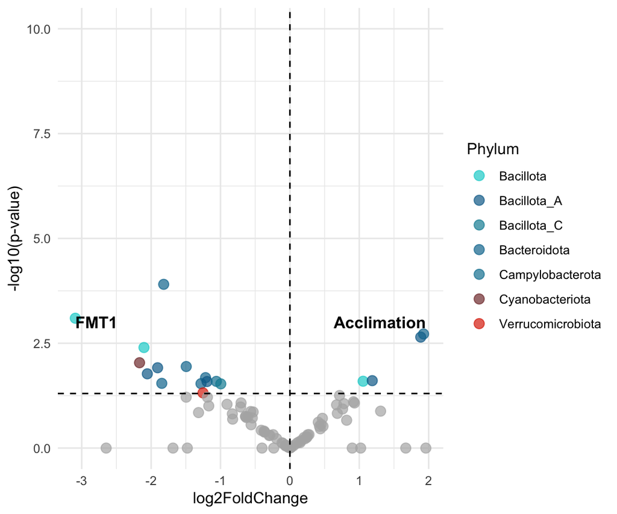

```r
ancombc_rand_table_mag %>%
  mutate(
    genome = factor(taxon, levels = ancombc_rand_table_mag$taxon),
    significance = ifelse(p_time_pointFMT1 < 0.05, phylum, NA)  # Set non-significant to NA (not mapped in legend)
  ) %>%
  ggplot() +
  # Plot significant points with legend
  geom_point(aes(x = lfc_time_pointFMT1, y = -log10(p_time_pointFMT1), color = significance),
             size = 3, alpha = 0.7, na.rm = TRUE) +
  # Plot non-significant points separately without legend
  geom_point(data = filter(ancombc_rand_table_mag, p_time_pointFMT1 >= 0.05),
             aes(x = lfc_time_pointFMT1, y = -log10(p_time_pointFMT1)),
             color = "grey70", size = 3, alpha = 0.7, show.legend = FALSE) +
  scale_color_manual(
    values = tax_color,  # Only keeps phylum colors in legend
    na.translate = FALSE  # Removes NA (non-significant) from legend
  ) +
  geom_hline(yintercept = -log10(0.05), linetype = "dashed") +
  geom_vline(xintercept = 0, linetype = "dashed") +
  scale_y_continuous(limits = c(0, 10)) +
  xlab("log2FoldChange") +
  ylab("-log10(p-value)") +
  guides(color = guide_legend(title = "Phylum")) +
  theme_minimal()+
  annotate("text", x = min(ancombc_rand_table_mag$lfc_time_pointFMT1), y = 3,
           label = "FMT1", hjust = 0, size = 4, fontface = "bold") +
  annotate("text", x = max(ancombc_rand_table_mag$lfc_time_pointFMT1), y = 3,
           label = "Acclimation", hjust = 1, size = 4, fontface = "bold")
```

*Phyla of the significant MAGs in acclimation*

```r
ancombc_rand_table_mag%>%
  filter(p_time_pointFMT1 < 0.05) %>%
  filter(lfc_time_pointFMT1>0)  %>%
  count(phylum, name = "sample_count") %>%
  arrange(desc(sample_count))
```

```
        phylum sample_count
1  Bacillota_A            2
2    Bacillota            1
3 Bacteroidota            1
```

*Phyla of the significant MAGs in FMT1*

```r
ancombc_rand_table_mag%>%
    filter(p_time_pointFMT1 < 0.05) %>%
  filter(lfc_time_pointFMT1<0)  %>%
  count(phylum, name = "sample_count") %>%
  arrange(desc(sample_count))
```

```
             phylum sample_count
1      Bacteroidota            5
2       Bacillota_A            3
3         Bacillota            2
4       Bacillota_C            1
5  Campylobacterota            1
6   Cyanobacteriota            1
7 Verrucomicrobiota            1
```

#### 9.2.2.2 CC: acclimation vs FMT1

*Structural zeros*

```r
struc <- structural_zeros %>%
  filter(present=="Acclimation")%>%
  count(phylum, name = "Acclimation") %>%
  arrange(desc(Acclimation))
structural_zeros %>%
  filter(present=="FMT1")%>%
  count(phylum, name = "FMT1") %>%
  arrange(desc(FMT1)) %>%
  full_join(., struc, by="phylum") %>%
  mutate(across(everything(), ~ ifelse(is.na(.), 0, .))) %>%
  tt()
```

| phylum | FMT1 | Acclimation |
| --- | --- | --- |
| p__Bacillota_A | 15 | 20 |
| p__Bacteroidota | 10 | 8 |
| p__Bacillota | 4 | 8 |
| p__Bacillota_C | 3 | 0 |
| p__Actinomycetota | 2 | 0 |
| p__Desulfobacterota | 1 | 1 |
| p__Fusobacteriota | 1 | 0 |
| p__Pseudomonadota | 1 | 6 |
| p__Cyanobacteriota | 0 | 3 |
| p__Verrucomicrobiota | 0 | 3 |
| p__Campylobacterota | 0 | 1 |

```r
phylo_samples <- sample_metadata %>%
  filter(type == "Control" & time_point %in% c("Acclimation", "FMT1") )%>%
  column_to_rownames("Tube_code") %>%
  sample_data()
phylo_genome <- genome_counts_filt %>%
  filter(!genome %in% structural_zeros$genome) %>%
  select(one_of(c("genome",rownames(phylo_samples)))) %>%
  filter(rowSums(across(where(is.numeric), ~ . != 0)) > 0) %>%
  select(genome, where(~ is.numeric(.) && sum(.) > 0)) %>%
  column_to_rownames("genome") %>%
  otu_table(., taxa_are_rows = TRUE)
phylo_taxonomy <- genome_metadata %>%
  filter(genome %in% rownames(phylo_genome)) %>%
  column_to_rownames("genome") %>%
  dplyr::select(domain,phylum,class,order,family,genus,species) %>%
  as.matrix() %>%
  tax_table()

physeq_genome_filtered <- phyloseq(phylo_genome, phylo_taxonomy, phylo_samples)
```

```r
ancom_rand_output_cc_accli_fmt1 = ancombc2(data = physeq_genome_filtered,
                  assay_name = "counts",
                  tax_level = NULL,
                  fix_formula = "time_point",
                  rand_formula = "(1|individual)",
                  p_adj_method = "holm",
                  pseudo_sens = TRUE,
                  prv_cut =0,
                  lib_cut = 0,
                  s0_perc = 0.05,
                  group = NULL,
                  struc_zero = FALSE,
                  neg_lb = FALSE,
                  alpha = 0.05,
                  n_cl = 2,
                  verbose = TRUE,
                  global = FALSE,
                  pairwise = FALSE,
                  dunnet = FALSE,
                  trend = FALSE,
                  iter_control = list(tol = 1e-5, max_iter = 20, verbose = FALSE),
                  em_control = list(tol = 1e-5, max_iter = 100),
                  lme_control = lme4::lmerControl(),
                  mdfdr_control = list(fwer_ctrl_method = "holm", B = 100),
                  trend_control = NULL)
```

```r
save(ancom_rand_output_cc_accli_fmt1, file="data/ancom_rand_output_cc_accli_fmt1.RData")
```

```r
load("data/ancom_rand_output_cc_accli_fmt1.RData")
```

```r
ancom_rand_output_cc_accli_fmt1$res %>%
  dplyr::select(taxon, lfc_time_pointFMT1, p_time_pointFMT1) %>%
  filter(p_time_pointFMT1 < 0.05) %>%
  left_join(., genome_metadata, by=join_by("taxon"=="genome")) %>%
  select(2,3,7,8,9) %>%
  tt()
```

| lfc_time_pointFMT1 | p_time_pointFMT1 | order | family | genus |
| --- | --- | --- | --- | --- |
| -0.05106234 | 1.087347e-03 | o__Bacteroidales | f__Rikenellaceae | g__Alistipes |
| -2.00983141 | 4.135734e-03 | o__Mycoplasmatales | f__Mycoplasmoidaceae | g__Mycoplasmoides |
| 0.34566268 | 1.734034e-08 | o__Rhizobiales | f__Rhizobiaceae | g__Agrobacterium |
| 1.16482511 | 1.499816e-02 | o__Lachnospirales | f__Lachnospiraceae | g__Clostridium_Q |
| 0.61551493 | 6.112591e-03 | o__Bacteroidales | f__Marinifilaceae | g__Odoribacter |
| -1.55576342 | 7.385690e-03 | o__Lachnospirales | f__Lachnospiraceae | g__Roseburia |
| 0.84351603 | 2.471203e-10 | o__Desulfovibrionales | f__Desulfovibrionaceae | g__Mailhella |
| -1.82483412 | 8.901467e-04 | o__Opitutales | f__LL51 | g__ |
| 2.39547299 | 3.716946e-03 | o__Bacteroidales | f__Tannerellaceae | g__Parabacteroides |
| -1.02615136 | 3.081813e-02 | o__Gastranaerophilales | f__Gastranaerophilaceae | g__Scatousia |
| 2.26880456 | 6.155443e-04 | o__Lachnospirales | f__Lachnospiraceae | g__ |
| 2.08639210 | 2.257694e-02 | o__Erysipelotrichales | f__Erysipelotrichaceae | g__Dielma |
| -0.15320881 | 2.894390e-07 | o__Oscillospirales | f__Acutalibacteraceae | g__ |
| 0.40216781 | 8.043863e-08 | o__Lachnospirales | f__Lachnospiraceae | g__Blautia |
| -0.31420642 | 3.503801e-02 | o__Bacteroidales | f__Bacteroidaceae | g__Bacteroides |
| 1.59121485 | 2.689122e-02 | o__Lachnospirales | f__Lachnospiraceae | g__Lacrimispora |
| 1.15237654 | 4.105427e-02 | o__Lachnospirales | f__Lachnospiraceae | g__Copromonas |
| 0.96788096 | 3.266235e-02 | o__Bacteroidales | f__Tannerellaceae | g__Parabacteroides |
| -1.62665913 | 6.927224e-10 | o__Lachnospirales | f__Lachnospiraceae | g__CAG-95 |
| -0.33476597 | 7.639704e-06 | o__Bacteroidales | f__Bacteroidaceae | g__ |
| 1.71086415 | 8.629735e-03 | o__Bacteroidales | f__Tannerellaceae | g__Parabacteroides |
| 1.69183592 | 1.540801e-03 | o__Bacteroidales | f__Bacteroidaceae | g__Bacteroides |

```r
taxonomy <- data.frame(physeq_genome_filtered@tax_table) %>%
  rownames_to_column(., "taxon") %>%
  mutate_at(vars(order, phylum, family, genus, species), ~ str_replace(., "[dpcofgs]__", ""))

ancombc_rand_table_mag <- ancom_rand_output_cc_accli_fmt1$res %>%
  dplyr::select(taxon, lfc_time_pointFMT1, p_time_pointFMT1) %>%
  #filter(p_time_pointFMT1 < 0.05) %>%
  dplyr::arrange(p_time_pointFMT1) %>%
  merge(., taxonomy, by="taxon") %>%
  mutate_at(vars(phylum, species), ~ str_replace(., "[dpcofgs]__", ""))%>%
  dplyr::arrange(lfc_time_pointFMT1)

ancombc_rand_table_mag
```

```
                    taxon lfc_time_pointFMT1 p_time_pointFMT1      domain            phylum                  class                order               family                genus                     species
1   AH1_2nd_12:bin_000041      -2.0098314057     4.135734e-03 d__Bacteria         Bacillota             c__Bacilli      Mycoplasmatales    Mycoplasmoidaceae       Mycoplasmoides
2   AH1_2nd_19:bin_000052      -1.8248341168     8.901467e-04 d__Bacteria Verrucomicrobiota    c__Verrucomicrobiae           Opitutales                 LL51
3    AH1_2nd_1:bin_000005      -1.6703353062     2.963969e-01 d__Bacteria       Bacillota_A          c__Clostridia       Lachnospirales      Lachnospiraceae
4   AH1_2nd_13:bin_000029      -1.6509016959     1.323946e-01 d__Bacteria    Pseudomonadota c__Alphaproteobacteria              UBA3830              UBA3830
5    AH1_2nd_8:bin_000006      -1.6266591275     6.927224e-10 d__Bacteria       Bacillota_A          c__Clostridia       Lachnospirales      Lachnospiraceae               CAG-95
6    AH1_2nd_7:bin_000015      -1.5768771619     9.018007e-02 d__Bacteria    Pseudomonadota c__Alphaproteobacteria                 RF32              CAG-239               CAZU01
7   AH1_2nd_19:bin_000005      -1.5557634212     7.385690e-03 d__Bacteria       Bacillota_A          c__Clostridia       Lachnospirales      Lachnospiraceae            Roseburia
8    LI1_2nd_1:bin_000014      -1.4459683538     6.299616e-02 d__Bacteria  Desulfobacterota    c__Desulfovibrionia   Desulfovibrionales  Desulfovibrionaceae
9    LI1_2nd_7:bin_000042      -1.2839852420     7.671653e-02 d__Bacteria      Bacteroidota         c__Bacteroidia        Bacteroidales       Tannerellaceae    Parabacteroides_B
10   AH1_2nd_1:bin_000003      -1.0261513612     3.081813e-02 d__Bacteria   Cyanobacteriota    c__Vampirovibrionia  Gastranaerophilales Gastranaerophilaceae            Scatousia
11  AH1_2nd_12:bin_000012      -0.8749431375     8.489977e-02 d__Bacteria  Campylobacterota     c__Campylobacteria    Campylobacterales    Helicobacteraceae       Helicobacter_J
12  AH1_2nd_12:bin_000056      -0.6610914186     4.690402e-01 d__Bacteria       Bacillota_A          c__Clostridia       Lachnospirales      Lachnospiraceae        Enterocloster
13   AH1_2nd_8:bin_000027      -0.4882381496     6.433405e-01 d__Bacteria         Bacillota             c__Bacilli   Erysipelotrichales  Erysipelotrichaceae               NSJ-61
14  AH1_2nd_15:bin_000043      -0.4810736412     5.802953e-01 d__Bacteria      Bacteroidota         c__Bacteroidia        Bacteroidales       Bacteroidaceae          Bacteroides
```

[output cut: 87 more lines]

```r
colors_alphabetic <- read_tsv("https://raw.githubusercontent.com/earthhologenome/EHI_taxonomy_colour/main/ehi_phylum_colors.tsv") %>%
  mutate_at(vars(phylum), ~ str_replace(., "[dpcofgs]__", ""))  %>%
  right_join(taxonomy, by=join_by(phylum == phylum)) %>%
  dplyr::select(phylum, colors) %>%
  mutate(colors = str_c(colors, "80"))  %>% #add 80% alpha
    unique() %>%
    dplyr::arrange(phylum)

tax_table <- as.data.frame(unique(ancombc_rand_table_mag$phylum))

colnames(tax_table)[1] <- "phylum"
tax_color <- merge(tax_table, colors_alphabetic, by="phylum")%>%
    dplyr::arrange(phylum) %>%
    dplyr::select(colors) %>%
    pull()
```

[figure not shown]

```r
ancombc_rand_table_mag %>%
  mutate(
    genome = factor(taxon, levels = ancombc_rand_table_mag$taxon),
    significance = ifelse(p_time_pointFMT1 < 0.05, phylum, NA)  # Set non-significant to NA (not mapped in legend)
  ) %>%
  ggplot() +
  # Plot significant points with legend
  geom_point(aes(x = lfc_time_pointFMT1, y = -log10(p_time_pointFMT1), color = significance),
             size = 3, alpha = 0.7, na.rm = TRUE) +
  # Plot non-significant points separately without legend
  geom_point(data = filter(ancombc_rand_table_mag, p_time_pointFMT1 >= 0.05),
             aes(x = lfc_time_pointFMT1, y = -log10(p_time_pointFMT1)),
             color = "grey70", size = 3, alpha = 0.7, show.legend = FALSE) +
  scale_color_manual(
    values = tax_color,  # Only keeps phylum colors in legend
    na.translate = FALSE  # Removes NA (non-significant) from legend
  ) +
  geom_hline(yintercept = -log10(0.05), linetype = "dashed") +
  geom_vline(xintercept = 0, linetype = "dashed") +
  scale_y_continuous(limits = c(0, 10)) +
  xlab("log2FoldChange") +
  ylab("-log10(p-value)") +
  guides(color = guide_legend(title = "Phylum")) +
  theme_minimal()+
  annotate("text", x = min(ancombc_rand_table_mag$lfc_time_pointFMT1), y = 10,
           label = "FMT1", hjust = 0, size = 4, fontface = "bold") +
  annotate("text", x = max(ancombc_rand_table_mag$lfc_time_pointFMT1), y = 10,
           label = "Acclimation", hjust = 1, size = 4, fontface = "bold")
```

*Phyla of the significant MAGs in acclimation*

```r
ancombc_rand_table_mag%>%
  filter(p_time_pointFMT1 < 0.05) %>%
  filter(lfc_time_pointFMT1>0)  %>%
  count(phylum, name = "sample_count") %>%
  arrange(desc(sample_count))
```

```
            phylum sample_count
1      Bacillota_A            5
2     Bacteroidota            5
3        Bacillota            1
4 Desulfobacterota            1
5   Pseudomonadota            1
```

*Phyla of the significant MAGs in FMT1*

```r
ancombc_rand_table_mag%>%
    filter(p_time_pointFMT1 < 0.05) %>%
  filter(lfc_time_pointFMT1<0)  %>%
  count(phylum, name = "sample_count") %>%
  arrange(desc(sample_count))
```

```
             phylum sample_count
1       Bacillota_A            3
2      Bacteroidota            3
3         Bacillota            1
4   Cyanobacteriota            1
5 Verrucomicrobiota            1
```

#### 9.2.2.3 WC: acclimation vs FMT1

*Structural zeros*

```r
struc <- structural_zeros %>%
  filter(present=="Acclimation")%>%
  count(phylum, name = "Acclimation") %>%
  arrange(desc(Acclimation))
structural_zeros %>%
  filter(present=="FMT1")%>%
  count(phylum, name = "FMT1") %>%
  arrange(desc(FMT1)) %>%
  full_join(., struc, by="phylum") %>%
  mutate(across(everything(), ~ ifelse(is.na(.), 0, .))) %>%
  tt()
```

| phylum | FMT1 | Acclimation |
| --- | --- | --- |
| p__Bacillota_A | 8 | 24 |
| p__Bacillota | 4 | 9 |
| p__Bacteroidota | 4 | 9 |
| p__Bacillota_C | 3 | 0 |
| p__Pseudomonadota | 2 | 7 |
| p__Desulfobacterota | 1 | 3 |
| p__Cyanobacteriota | 0 | 4 |
| p__Verrucomicrobiota | 0 | 2 |
| p__Bacillota_B | 0 | 1 |

```r
phylo_samples <- sample_metadata %>%
  filter(type == "Hot_control" & time_point %in% c("Acclimation", "FMT1") )%>%
  column_to_rownames("Tube_code") %>%
  sample_data()
phylo_genome <- genome_counts_filt %>%
  filter(!genome %in% structural_zeros$genome) %>%
  select(one_of(c("genome",rownames(phylo_samples)))) %>%
  filter(rowSums(across(where(is.numeric), ~ . != 0)) > 0) %>%
  select(genome, where(~ is.numeric(.) && sum(.) > 0)) %>%
  column_to_rownames("genome") %>%
  otu_table(., taxa_are_rows = TRUE)
phylo_taxonomy <- genome_metadata %>%
  filter(genome %in% rownames(phylo_genome)) %>%
  column_to_rownames("genome") %>%
  dplyr::select(domain,phylum,class,order,family,genus,species) %>%
  as.matrix() %>%
  tax_table()

physeq_genome_filtered <- phyloseq(phylo_genome, phylo_taxonomy, phylo_samples)
```

```r
ancom_rand_output_wc_accli_fmt1 = ancombc2(data = physeq_genome_filtered,
                  assay_name = "counts",
                  tax_level = NULL,
                  fix_formula = "time_point",
                  p_adj_method = "holm",
                  pseudo_sens = TRUE,
                  prv_cut =0,
                  lib_cut = 0,
                  s0_perc = 0.05,
                  group = NULL,
                  struc_zero = FALSE,
                  neg_lb = FALSE,
                  alpha = 0.05,
                  n_cl = 2,
                  verbose = TRUE,
                  global = FALSE,
                  pairwise = FALSE,
                  dunnet = FALSE,
                  trend = FALSE,
                  iter_control = list(tol = 1e-5, max_iter = 20, verbose = FALSE),
                  em_control = list(tol = 1e-5, max_iter = 100),
                  mdfdr_control = list(fwer_ctrl_method = "holm", B = 100),
                  trend_control = NULL)
```

```r
save(ancom_rand_output_wc_accli_fmt1, file="data/ancom_rand_output_wc_accli_fmt1.RData")
```

```r
load("data/ancom_rand_output_wc_accli_fmt1.RData")
```

```r
ancom_rand_output_wc_accli_fmt1$res %>%
  dplyr::select(taxon, lfc_time_pointFMT1, p_time_pointFMT1) %>%
  filter(p_time_pointFMT1 < 0.05) %>%
  left_join(., genome_metadata, by=join_by("taxon"=="genome")) %>%
  select(2,3,7,8,9) %>%
  tt()
```

[output not shown]

```r
taxonomy <- data.frame(physeq_genome_filtered@tax_table) %>%
  rownames_to_column(., "taxon") %>%
  mutate_at(vars(order, phylum, family, genus, species), ~ str_replace(., "[dpcofgs]__", ""))

ancombc_rand_table_mag <- ancom_rand_output_wc_accli_fmt1$res %>%
  dplyr::select(taxon, lfc_time_pointFMT1, p_time_pointFMT1) %>%
  #filter(p_time_pointFMT1 < 0.05) %>%
  dplyr::arrange(p_time_pointFMT1) %>%
  merge(., taxonomy, by="taxon") %>%
  mutate_at(vars(phylum, species), ~ str_replace(., "[dpcofgs]__", ""))%>%
  dplyr::arrange(lfc_time_pointFMT1)

ancombc_rand_table_mag
```

```
                   taxon lfc_time_pointFMT1 p_time_pointFMT1      domain           phylum                  class               order               family             genus                      species
1  AH1_2nd_18:bin_000011        -3.09238298     0.0007999100 d__Bacteria        Bacillota             c__Bacilli  Erysipelotrichales     Coprobacillaceae     Coprobacillus
2   AH1_2nd_2:bin_000003        -2.64816145     1.0000000000 d__Bacteria      Bacillota_A          c__Clostridia      Lachnospirales      Lachnospiraceae          JAAYNV01
3   AH1_2nd_1:bin_000003        -2.16684429     0.0092167448 d__Bacteria  Cyanobacteriota    c__Vampirovibrionia Gastranaerophilales Gastranaerophilaceae         Scatousia
4   LI1_2nd_4:bin_000001        -2.05486750     0.0169404933 d__Bacteria      Bacillota_A          c__Clostridia  Christensenellales
5   AH1_2nd_8:bin_000006        -1.90640581     0.0121488844 d__Bacteria      Bacillota_A          c__Clostridia      Lachnospirales      Lachnospiraceae            CAG-95
6   LI1_2nd_4:bin_000026        -1.81895155     0.0001244128 d__Bacteria     Bacteroidota         c__Bacteroidia       Bacteroidales       Marinifilaceae       Odoribacter
7  AH1_2nd_19:bin_000011        -1.49472687     0.0611399521 d__Bacteria Desulfobacterota    c__Desulfovibrionia  Desulfovibrionales  Desulfovibrionaceae         Mailhella
8   LI1_2nd_7:bin_000042        -1.49376217     0.0113515485 d__Bacteria     Bacteroidota         c__Bacteroidia       Bacteroidales       Tannerellaceae Parabacteroides_B
9  AH1_2nd_19:bin_000072        -1.47826887     1.0000000000 d__Bacteria      Bacillota_A          c__Clostridia      Lachnospirales      Lachnospiraceae
10 AH1_2nd_14:bin_000015        -1.31675396     0.1424337358 d__Bacteria      Bacillota_A          c__Clostridia  Christensenellales              UBA3700
11  AH1_2nd_1:bin_000039        -1.28118772     0.0290779856 d__Bacteria     Bacteroidota         c__Bacteroidia       Bacteroidales       Marinifilaceae       Odoribacter
12 AH1_2nd_14:bin_000003        -1.19373604     0.0258952249 d__Bacteria      Bacillota_A          c__Clostridia      Lachnospirales      Lachnospiraceae      Hungatella_A
13 AH1_2nd_18:bin_000024        -1.18873116     0.0611452591 d__Bacteria     Bacteroidota         c__Bacteroidia       Bacteroidales       Marinifilaceae       Odoribacter
14  AH1_2nd_9:bin_000002        -1.16920978     0.0986538496 d__Bacteria     Bacteroidota         c__Bacteroidia       Bacteroidales       Bacteroidaceae       Phocaeicola
```

[output cut: 52 more lines]

```r
colors_alphabetic <- read_tsv("https://raw.githubusercontent.com/earthhologenome/EHI_taxonomy_colour/main/ehi_phylum_colors.tsv") %>%
  mutate_at(vars(phylum), ~ str_replace(., "[dpcofgs]__", ""))  %>%
  right_join(taxonomy, by=join_by(phylum == phylum)) %>%
  dplyr::select(phylum, colors) %>%
  mutate(colors = str_c(colors, "80"))  %>% #add 80% alpha
    unique() %>%
    dplyr::arrange(phylum)

tax_table <- as.data.frame(unique(ancombc_rand_table_mag$phylum))

colnames(tax_table)[1] <- "phylum"
tax_color <- merge(tax_table, colors_alphabetic, by="phylum")%>%
    dplyr::arrange(phylum) %>%
    dplyr::select(colors) %>%
    pull()
```

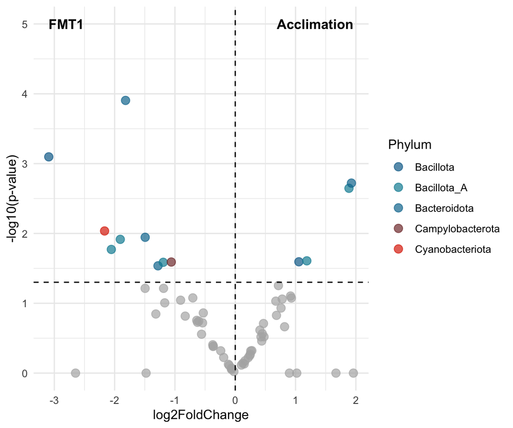

```r
ancombc_rand_table_mag %>%
  mutate(
    genome = factor(taxon, levels = ancombc_rand_table_mag$taxon),
    significance = ifelse(p_time_pointFMT1 < 0.05, phylum, NA)  # Set non-significant to NA (not mapped in legend)
  ) %>%
  ggplot() +
  # Plot significant points with legend
  geom_point(aes(x = lfc_time_pointFMT1, y = -log10(p_time_pointFMT1), color = significance),
             size = 3, alpha = 0.7, na.rm = TRUE) +
  # Plot non-significant points separately without legend
  geom_point(data = filter(ancombc_rand_table_mag, p_time_pointFMT1 >= 0.05),
             aes(x = lfc_time_pointFMT1, y = -log10(p_time_pointFMT1)),
             color = "grey70", size = 3, alpha = 0.7, show.legend = FALSE) +
  scale_color_manual(
    values = tax_color,  # Only keeps phylum colors in legend
    na.translate = FALSE  # Removes NA (non-significant) from legend
  ) +
  geom_hline(yintercept = -log10(0.05), linetype = "dashed") +
  geom_vline(xintercept = 0, linetype = "dashed") +
  scale_y_continuous(limits = c(0, 5)) +
  xlab("log2FoldChange") +
  ylab("-log10(p-value)") +
  guides(color = guide_legend(title = "Phylum")) +
  theme_minimal()+
  annotate("text", x = min(ancombc_rand_table_mag$lfc_time_pointFMT1), y = 5,
           label = "FMT1", hjust = 0, size = 4, fontface = "bold") +
  annotate("text", x = max(ancombc_rand_table_mag$lfc_time_pointFMT1), y = 5,
           label = "Acclimation", hjust = 1, size = 4, fontface = "bold")
```

*Phyla of the significant MAGs in acclimation*

```r
ancombc_rand_table_mag%>%
  filter(p_time_pointFMT1 < 0.05) %>%
  filter(lfc_time_pointFMT1>0)  %>%
  count(phylum, name = "sample_count") %>%
  arrange(desc(sample_count))
```

```
        phylum sample_count
1  Bacillota_A            2
2    Bacillota            1
3 Bacteroidota            1
```

*Phyla of the significant MAGs in FMT1*

```r
ancombc_rand_table_mag%>%
  filter(p_time_pointFMT1 < 0.05) %>%
  filter(lfc_time_pointFMT1<0)  %>%
  count(phylum, name = "sample_count") %>%
  arrange(desc(sample_count))
```

```
            phylum sample_count
1      Bacillota_A            3
2     Bacteroidota            3
3        Bacillota            1
4 Campylobacterota            1
5  Cyanobacteriota            1
```

## 9.3 Differences between FMT1 and FMT2 across the three experimental groups

### 9.3.1 Functional differences

*CI from FMT1 to FMT2*

```r
significant_element<-element_gift %>%
  filter(time_point %in% c("FMT2","FMT1") & type == "Treatment") %>%
  select(-time_point, -type) %>%
  filter(rowSums(across(where(is.numeric), ~ . != 0)) > 0) %>%
  select(Tube_code, where( ~ is.numeric(.) && sum(.) > 0)) %>%
  left_join(sample_metadata[c(1, 10)], by = "Tube_code") %>%
  pivot_longer(-c(Tube_code, time_point),
               names_to = "trait",
               values_to = "value") %>%
  group_by(trait) %>%
  summarise(p_value = wilcox.test(value ~ time_point)$p.value) %>%
  mutate(p_adjust = p.adjust(p_value, method = "BH")) %>%
  filter(p_adjust < 0.05) %>%
  remove_rownames() %>%
  left_join(., uniqueGIFT_db, by=join_by("trait"=="Code_element"))
```

```r
element_gift_sig <- element_gift %>%
  select(Tube_code, all_of(intersect(
    significant_element$trait,
    colnames(element_gift)
  ))) %>%
  left_join(., sample_metadata[c(1, 7, 10)], by = join_by(Tube_code == Tube_code)) %>%
  filter(time_point %in% c("FMT2","FMT1"))%>%
  filter(type=="Treatment")

difference_table <- element_gift_sig %>%
  select(-Tube_code, -type) %>%
  group_by(time_point) %>%
  summarise(across(everything(), mean)) %>%
  t() %>%
  row_to_names(row_number = 1) %>%
  as.data.frame() %>%
  mutate_if(is.character, as.numeric) %>%
  rownames_to_column(., "Elements") %>%
  left_join(.,uniqueGIFT_db[c(1,3,4)],by = join_by(Elements == Code_element)) %>%
  arrange(Function) %>%
  mutate(Difference=FMT1-FMT2)%>%
  mutate(group_color = ifelse(Difference <0,"FMT2", "FMT1"))
```

[figure not shown]

```r
difference_table %>%
  ggplot(aes(x=forcats::fct_reorder(Function,Difference), y=Difference, fill=group_color)) +
  geom_col() +
  scale_fill_manual(values=c('#008080',"#76b183")) +
  geom_hline(yintercept=0) +
  coord_flip()+
  theme(axis.text = element_text(size = 10),
        axis.title = element_text(size = 12),
        legend.position = "right",
        legend.title = element_blank(),
        panel.background = element_blank(),
        panel.grid.major = element_line(size = 0.15, linetype = 'solid',
                                        colour = "grey"))+
  xlab("Function") +
  ylab("Mean difference")
```

*CC from FMT1 to FMT2*

```r
element_gift %>%
  filter(time_point %in% c("FMT2","FMT1") & type == "Control") %>%
  select(-time_point, -type) %>%
  filter(rowSums(across(where(is.numeric), ~ . != 0)) > 0) %>%
  select(Tube_code, where( ~ is.numeric(.) && sum(.) > 0)) %>%
  left_join(sample_metadata[c(1, 10)], by = "Tube_code") %>%
  pivot_longer(-c(Tube_code, time_point),
               names_to = "trait",
               values_to = "value") %>%
  group_by(trait) %>%
  summarise(p_value = wilcox.test(value ~ time_point)$p.value) %>%
  mutate(p_adjust = p.adjust(p_value, method = "BH")) %>%
  filter(p_adjust < 0.05) %>%
  remove_rownames() %>%
  left_join(., uniqueGIFT_db, by=join_by("trait"=="Code_element"))
```

```
# A tibble: 0 × 6
# ℹ 6 variables: trait <chr>, p_value <dbl>, p_adjust <dbl>, Domain <chr>, Function <chr>, Element <chr>
```

*WC from FMT1 to FMT2*

```r
element_gift %>%
  filter(time_point %in% c("FMT2","FMT1") & type == "Hot_control") %>%
  select(-time_point, -type) %>%
  filter(rowSums(across(where(is.numeric), ~ . != 0)) > 0) %>%
  select(Tube_code, where( ~ is.numeric(.) && sum(.) > 0)) %>%
  left_join(sample_metadata[c(1, 10)], by = "Tube_code") %>%
  pivot_longer(-c(Tube_code, time_point),
               names_to = "trait",
               values_to = "value") %>%
  group_by(trait) %>%
  summarise(p_value = wilcox.test(value ~ time_point)$p.value) %>%
  mutate(p_adjust = p.adjust(p_value, method = "BH")) %>%
  filter(p_adjust < 0.05) %>%
  remove_rownames() %>%
  left_join(., uniqueGIFT_db, by=join_by("trait"=="Code_element"))
```

```
# A tibble: 0 × 6
# ℹ 6 variables: trait <chr>, p_value <dbl>, p_adjust <dbl>, Domain <chr>, Function <chr>, Element <chr>
```

### 9.3.2 Differential abundances

#### 9.3.2.1 CI: FMT1 vs FMT2

*Structural zeros*

```r
struc <- structural_zeros %>%
  filter(present=="FMT1")%>%
  count(phylum, name = "FMT1") %>%
  arrange(desc(FMT1))
structural_zeros %>%
  filter(present=="FMT2")%>%
  count(phylum, name = "FMT2") %>%
  arrange(desc(FMT2)) %>%
  full_join(., struc, by="phylum") %>%
  mutate(across(everything(), ~ ifelse(is.na(.), 0, .))) %>%
  tt()
```

| phylum | FMT2 | FMT1 |
| --- | --- | --- |
| p__Bacillota_A | 19 | 8 |
| p__Pseudomonadota | 15 | 0 |
| p__Bacteroidota | 8 | 2 |
| p__Bacillota | 5 | 3 |
| p__Cyanobacteriota | 5 | 0 |
| p__Desulfobacterota | 2 | 0 |
| p__Verrucomicrobiota | 2 | 0 |
| p__Bacillota_C | 1 | 0 |
| p__Spirochaetota | 1 | 0 |
| p__Actinomycetota | 0 | 1 |
| p__Campylobacterota | 0 | 1 |

```r
phylo_samples <- sample_metadata %>%
  filter(type == "Treatment" & time_point %in% c("FMT1", "FMT2") )%>%
  column_to_rownames("Tube_code") %>%
  sample_data()
phylo_genome <- genome_counts_filt %>%
  filter(!genome %in% structural_zeros$genome) %>%
  select(one_of(c("genome",rownames(phylo_samples)))) %>%
  filter(rowSums(across(where(is.numeric), ~ . != 0)) > 0) %>%
  select(genome, where(~ is.numeric(.) && sum(.) > 0)) %>%
  column_to_rownames("genome") %>%
  otu_table(., taxa_are_rows = TRUE)
phylo_taxonomy <- genome_metadata %>%
  filter(genome %in% rownames(phylo_genome)) %>%
  column_to_rownames("genome") %>%
  dplyr::select(domain,phylum,class,order,family,genus,species) %>%
  as.matrix() %>%
  tax_table()

physeq_genome_filtered <- phyloseq(phylo_genome, phylo_taxonomy, phylo_samples)
```

```r
ancom_rand_output_ci_fmt1_FMT2 = ancombc2(data = physeq_genome_filtered,
                  assay_name = "counts",
                  tax_level = NULL,
                  fix_formula = "time_point",
                  p_adj_method = "holm",
                  pseudo_sens = TRUE,
                  prv_cut =0,
                  lib_cut = 0,
                  s0_perc = 0.05,
                  group = NULL,
                  struc_zero = FALSE,
                  neg_lb = FALSE,
                  alpha = 0.05,
                  n_cl = 2,
                  verbose = TRUE,
                  global = FALSE,
                  pairwise = FALSE,
                  dunnet = FALSE,
                  trend = FALSE,
                  iter_control = list(tol = 1e-5, max_iter = 20, verbose = FALSE),
                  em_control = list(tol = 1e-5, max_iter = 100),
                  mdfdr_control = list(fwer_ctrl_method = "holm", B = 100),
                  trend_control = NULL)
```

```r
save(ancom_rand_output_ci_fmt1_FMT2, file="data/ancom_rand_output_ci_fmt1_FMT2.RData")
```

```r
load("data/ancom_rand_output_ci_fmt1_FMT2.RData")
```

```r
ancom_rand_output_ci_fmt1_FMT2$res %>%
  dplyr::select(taxon, lfc_time_pointFMT2, p_time_pointFMT2) %>%
  filter(p_time_pointFMT2 < 0.05) %>%
  left_join(., genome_metadata, by=join_by("taxon"=="genome")) %>%
  select(2,3,7,8,9) %>%
  tt()
```

| lfc_time_pointFMT2 | p_time_pointFMT2 | order | family | genus |
| --- | --- | --- | --- | --- |
| 1.6049257 | 0.0157811865 | o__Gastranaerophilales | f__Gastranaerophilaceae | g__Limenecus |
| 0.9564973 | 0.0275097081 | o__Bacteroidales | f__Tannerellaceae | g__Parabacteroides |
| 2.0492182 | 0.0166204040 | o__Lachnospirales | f__Lachnospiraceae | g__Hungatella_A |
| -1.8918089 | 0.0096699943 | o__Campylobacterales | f__Helicobacteraceae | g__Helicobacter_J |
| -1.2081046 | 0.0210589073 | o__RF32 | f__CAG-239 | g__MGBC133411 |
| 1.1513092 | 0.0219338284 | o__Bacteroidales | f__Bacteroidaceae | g__Bacteroides |
| 1.9022386 | 0.0009678398 | o__Lachnospirales | f__Lachnospiraceae | g__Hungatella_A |
| -1.1428833 | 0.0226212068 | o__Rhizobiales | f__Rhizobiaceae | g__Agrobacterium |
| 1.5906273 | 0.0008227118 | o__Lachnospirales | f__Lachnospiraceae | g__Acetatifactor |
| 1.0975241 | 0.0150004122 | o__Oscillospirales | f__Oscillospiraceae | g__Scatomorpha |
| -1.0241243 | 0.0081256230 | o__Lachnospirales | f__Lachnospiraceae | g__ |
| 1.1899452 | 0.0392264054 | o__Bacteroidales | f__Marinifilaceae | g__Odoribacter |
| 2.3003362 | 0.0160580780 | o__Bacteroidales | f__Rikenellaceae | g__Alistipes |
| -1.1771426 | 0.0398005716 | o__Bacteroidales | f__Bacteroidaceae | g__Bacteroides |
| 2.1549960 | 0.0063980102 | o__Enterobacterales | f__Enterobacteriaceae | g__Proteus |
| 1.1806298 | 0.0153184259 | o__Lachnospirales | f__Lachnospiraceae | g__CAG-95 |
| 0.9643164 | 0.0213552124 | o__Bacteroidales | f__Bacteroidaceae | g__Bacteroides |
| 0.9715614 | 0.0148063589 | o__Desulfovibrionales | f__Desulfovibrionaceae | g__ |
| 1.4550695 | 0.0288178503 | o__Christensenellales | f__ | g__ |
| 1.6826957 | 0.0003988880 | o__Bacteroidales | f__Marinifilaceae | g__Odoribacter |
| -1.7750818 | 0.0188386554 | o__Bacteroidales | f__Rikenellaceae | g__Alistipes |
| -1.0206596 | 0.0387357946 | o__Erysipelotrichales | f__Erysipelotrichaceae | g__Clostridium_AQ |
| 1.6686679 | 0.0064021556 | o__Lachnospirales | f__Lachnospiraceae | g__ |
| 1.2527317 | 0.0339066213 | o__RF32 | f__CAG-239 | g__CAJLXD01 |
| 1.1133229 | 0.0229428387 | o__Oscillospirales | f__Oscillospiraceae | g__Oscillibacter |

```r
taxonomy <- data.frame(physeq_genome_filtered@tax_table) %>%
  rownames_to_column(., "taxon") %>%
  mutate_at(vars(order, phylum, family, genus, species), ~ str_replace(., "[dpcofgs]__", ""))

ancombc_rand_table_mag <- ancom_rand_output_ci_fmt1_FMT2$res %>%
  dplyr::select(taxon, lfc_time_pointFMT2, p_time_pointFMT2) %>%
  #filter(p_time_pointFMT2 < 0.05) %>%
  dplyr::arrange(p_time_pointFMT2) %>%
  merge(., taxonomy, by="taxon") %>%
  mutate_at(vars(phylum, species), ~ str_replace(., "[dpcofgs]__", ""))%>%
  dplyr::arrange(lfc_time_pointFMT2)

ancombc_rand_table_mag
```

```
                    taxon lfc_time_pointFMT2 p_time_pointFMT2      domain           phylum                  class                order               family                 genus                           species
1    AH1_2nd_2:bin_000018      -2.2170598063      1.000000000 d__Bacteria  Elusimicrobiota       c__Elusimicrobia     Elusimicrobiales    Elusimicrobiaceae               UBA1436
2   AH1_2nd_12:bin_000012      -1.8918089133      0.009669994 d__Bacteria Campylobacterota     c__Campylobacteria    Campylobacterales    Helicobacteraceae        Helicobacter_J
3    LI1_2nd_7:bin_000012      -1.7750818207      0.018838655 d__Bacteria     Bacteroidota         c__Bacteroidia        Bacteroidales        Rikenellaceae             Alistipes
4    AH1_2nd_1:bin_000034      -1.6789181354      0.122732881 d__Bacteria        Bacillota             c__Bacilli   Erysipelotrichales  Erysipelotrichaceae                Dielma
5    AH1_2nd_2:bin_000017      -1.6426716470      0.099339305 d__Bacteria      Bacillota_A          c__Clostridia       Lachnospirales      Lachnospiraceae            Copromonas
6   AH1_2nd_12:bin_000007      -1.3317033001      0.149416168 d__Bacteria      Bacillota_A          c__Clostridia       Lachnospirales      Lachnospiraceae
7   AH1_2nd_13:bin_000049      -1.2129524427      1.000000000 d__Bacteria      Bacillota_A          c__Clostridia   Christensenellales              UBA3700
8   AH1_2nd_13:bin_000011      -1.2081045846      0.021058907 d__Bacteria   Pseudomonadota c__Alphaproteobacteria                 RF32              CAG-239            MGBC133411
9    AH1_2nd_6:bin_000046      -1.1771425789      0.039800572 d__Bacteria     Bacteroidota         c__Bacteroidia        Bacteroidales       Bacteroidaceae           Bacteroides
10  AH1_2nd_15:bin_000001      -1.1428833092      0.022621207 d__Bacteria   Pseudomonadota c__Alphaproteobacteria          Rhizobiales         Rhizobiaceae         Agrobacterium       Agrobacterium tumefaciens_H
11   AH1_2nd_1:bin_000023      -1.0241242829      0.008125623 d__Bacteria      Bacillota_A          c__Clostridia       Lachnospirales      Lachnospiraceae
12   LI1_2nd_7:bin_000016      -1.0206596135      0.038735795 d__Bacteria        Bacillota             c__Bacilli   Erysipelotrichales  Erysipelotrichaceae        Clostridium_AQ
13  AH1_2nd_16:bin_000020      -0.8225875416      0.125186659 d__Bacteria Desulfobacterota    c__Desulfovibrionia   Desulfovibrionales  Desulfovibrionaceae             Bilophila
14   LI1_2nd_4:bin_000036      -0.7526182338      0.126502547 d__Bacteria     Bacteroidota         c__Bacteroidia        Bacteroidales       Bacteroidaceae
```

[output cut: 87 more lines]

```r
colors_alphabetic <- read_tsv("https://raw.githubusercontent.com/earthhologenome/EHI_taxonomy_colour/main/ehi_phylum_colors.tsv") %>%
  mutate_at(vars(phylum), ~ str_replace(., "[dpcofgs]__", ""))  %>%
  right_join(taxonomy, by=join_by(phylum == phylum)) %>%
  dplyr::select(phylum, colors) %>%
  mutate(colors = str_c(colors, "80"))  %>% #add 80% alpha
    unique() %>%
    dplyr::arrange(phylum)

tax_table <- as.data.frame(unique(ancombc_rand_table_mag$phylum))

colnames(tax_table)[1] <- "phylum"
tax_color <- merge(tax_table, colors_alphabetic, by="phylum")%>%
    dplyr::arrange(phylum) %>%
    dplyr::select(colors) %>%
    pull()
```

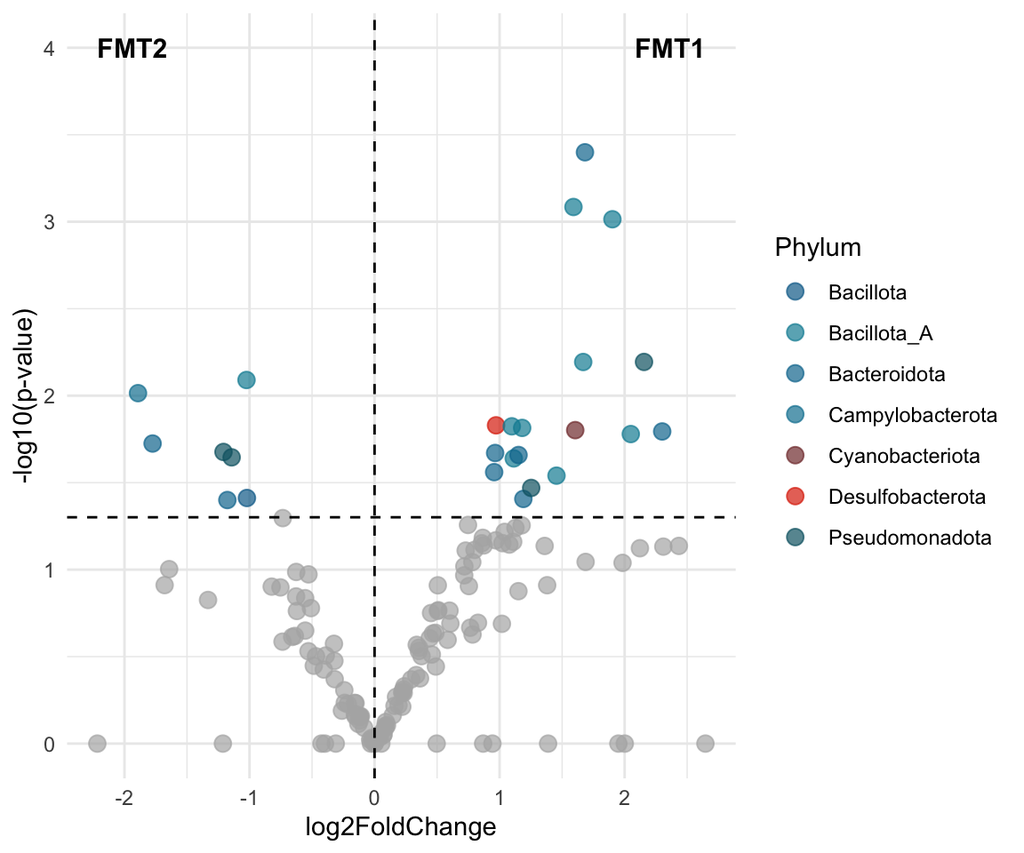

```r
ancombc_rand_table_mag %>%
  mutate(
    genome = factor(taxon, levels = ancombc_rand_table_mag$taxon),
    significance = ifelse(p_time_pointFMT2 < 0.05, phylum, NA)  # Set non-significant to NA (not mapped in legend)
  ) %>%
  ggplot() +
  # Plot significant points with legend
  geom_point(aes(x = lfc_time_pointFMT2, y = -log10(p_time_pointFMT2), color = significance),
             size = 3, alpha = 0.7, na.rm = TRUE) +
  # Plot non-significant points separately without legend
  geom_point(data = filter(ancombc_rand_table_mag, p_time_pointFMT2 >= 0.05),
             aes(x = lfc_time_pointFMT2, y = -log10(p_time_pointFMT2)),
             color = "grey70", size = 3, alpha = 0.7, show.legend = FALSE) +
  scale_color_manual(
    values = tax_color,  # Only keeps phylum colors in legend
    na.translate = FALSE  # Removes NA (non-significant) from legend
  ) +
  geom_hline(yintercept = -log10(0.05), linetype = "dashed") +
  geom_vline(xintercept = 0, linetype = "dashed") +
  scale_y_continuous(limits = c(0, 4)) +
  xlab("log2FoldChange") +
  ylab("-log10(p-value)") +
  guides(color = guide_legend(title = "Phylum")) +
  theme_minimal()+
  annotate("text", x = min(ancombc_rand_table_mag$lfc_time_pointFMT2), y = 4,
           label = "FMT2", hjust = 0, size = 4, fontface = "bold") +
  annotate("text", x = max(ancombc_rand_table_mag$lfc_time_pointFMT2), y = 4,
           label = "FMT1", hjust = 1, size = 4, fontface = "bold")
```

*Phyla of the significant MAGs in FMT1*

```r
ancombc_rand_table_mag%>%
  filter(p_time_pointFMT2 < 0.05) %>%
  filter(lfc_time_pointFMT2>0)  %>%
  count(phylum, name = "sample_count") %>%
  arrange(desc(sample_count))
```

```
            phylum sample_count
1      Bacillota_A            8
2     Bacteroidota            6
3   Pseudomonadota            2
4  Cyanobacteriota            1
5 Desulfobacterota            1
```

*Phyla of the significant MAGs in FMT2*

```r
ancombc_rand_table_mag%>%
  filter(p_time_pointFMT2 < 0.05) %>%
  filter(lfc_time_pointFMT2<0)  %>%
  count(phylum, name = "sample_count") %>%
  arrange(desc(sample_count))
```

```
            phylum sample_count
1     Bacteroidota            2
2   Pseudomonadota            2
3        Bacillota            1
4      Bacillota_A            1
5 Campylobacterota            1
```

#### 9.3.2.2 CC: FMT1 vs FMT2

*Structural zeros*

```r
struc <- structural_zeros %>%
  filter(present=="FMT1")%>%
  count(phylum, name = "FMT1") %>%
  arrange(desc(FMT1))
structural_zeros %>%
  filter(present=="FMT2")%>%
  count(phylum, name = "FMT2") %>%
  arrange(desc(FMT2)) %>%
  full_join(., struc, by="phylum") %>%
  mutate(across(everything(), ~ ifelse(is.na(.), 0, .))) %>%
  tt()
```

| phylum | FMT2 | FMT1 |
| --- | --- | --- |
| p__Bacillota_A | 19 | 6 |
| p__Bacillota | 6 | 4 |
| p__Bacteroidota | 6 | 6 |
| p__Pseudomonadota | 6 | 1 |
| p__Cyanobacteriota | 2 | 0 |
| p__Desulfobacterota | 2 | 1 |
| p__Campylobacterota | 1 | 0 |
| p__Verrucomicrobiota | 1 | 0 |
| p__Actinomycetota | 0 | 1 |

```r
phylo_samples <- sample_metadata %>%
  filter(type == "Control" & time_point %in% c("FMT1", "FMT2") )%>%
  column_to_rownames("Tube_code") %>%
  sample_data()
phylo_genome <- genome_counts_filt %>%
  filter(!genome %in% structural_zeros$genome) %>%
  select(one_of(c("genome",rownames(phylo_samples)))) %>%
  filter(rowSums(across(where(is.numeric), ~ . != 0)) > 0) %>%
  select(genome, where(~ is.numeric(.) && sum(.) > 0)) %>%
  column_to_rownames("genome") %>%
  otu_table(., taxa_are_rows = TRUE)
phylo_taxonomy <- genome_metadata %>%
  filter(genome %in% rownames(phylo_genome)) %>%
  column_to_rownames("genome") %>%
  dplyr::select(domain,phylum,class,order,family,genus,species) %>%
  as.matrix() %>%
  tax_table()

physeq_genome_filtered <- phyloseq(phylo_genome, phylo_taxonomy, phylo_samples)
```

```r
ancom_rand_output_cc_fmt1_FMT2 = ancombc2(data = physeq_genome_filtered,
                  assay_name = "counts",
                  tax_level = NULL,
                  fix_formula = "time_point",
                  p_adj_method = "holm",
                  pseudo_sens = TRUE,
                  prv_cut =0,
                  lib_cut = 0,
                  s0_perc = 0.05,
                  group = NULL,
                  struc_zero = FALSE,
                  neg_lb = FALSE,
                  alpha = 0.05,
                  n_cl = 2,
                  verbose = TRUE,
                  global = FALSE,
                  pairwise = FALSE,
                  dunnet = FALSE,
                  trend = FALSE,
                  iter_control = list(tol = 1e-5, max_iter = 20, verbose = FALSE),
                  em_control = list(tol = 1e-5, max_iter = 100),
                  mdfdr_control = list(fwer_ctrl_method = "holm", B = 100),
                  trend_control = NULL)
```

```r
save(ancom_rand_output_cc_fmt1_FMT2, file="data/ancom_rand_output_cc_fmt1_FMT2.RData")
```

```r
load("data/ancom_rand_output_cc_fmt1_FMT2.RData")
```

```r
ancom_rand_output_cc_fmt1_FMT2$res %>%
  dplyr::select(taxon, lfc_time_pointFMT2, p_time_pointFMT2) %>%
  filter(p_time_pointFMT2 < 0.05) %>%
  left_join(., genome_metadata, by=join_by("taxon"=="genome")) %>%
  select(2,3,7,8,9) %>%
  tt()
```

| lfc_time_pointFMT2 | p_time_pointFMT2 | order | family | genus |
| --- | --- | --- | --- | --- |
| -1.1198010 | 0.0493049214 | o__Gastranaerophilales | f__Gastranaerophilaceae | g__CALURL01 |
| -1.5062750 | 0.0097993771 | o__Fusobacteriales | f__Fusobacteriaceae | g__Fusobacterium_A |
| 2.4827509 | 0.0139900313 | o__RF32 | f__CAG-239 | g__Scatocola |
| -1.3151251 | 0.0072517933 | o__Lactobacillales | f__Streptococcaceae | g__Lactococcus |
| 1.4541589 | 0.0160901322 | o__Bacteroidales | f__Rikenellaceae | g__Alistipes |
| -0.8116835 | 0.0444836721 | o__Bacteroidales | f__Rikenellaceae | g__Alistipes |
| 1.1136172 | 0.0250850130 | o__Mycoplasmatales | f__Mycoplasmoidaceae | g__Mycoplasmoides |
| -1.3597164 | 0.0258606259 | o__Rhizobiales | f__Rhizobiaceae | g__Agrobacterium |
| 1.1091976 | 0.0164391414 | o__Gastranaerophilales | f__Gastranaerophilaceae | g__Limenecus |
| -0.9340069 | 0.0351897805 | o__Lachnospirales | f__Lachnospiraceae | g__Clostridium_Q |
| -1.5761511 | 0.0087725684 | o__Erysipelotrichales | f__Erysipelotrichaceae | g__NSJ-61 |
| 1.6900744 | 0.0007465450 | o__Bacteroidales | f__Tannerellaceae | g__Parabacteroides |
| -2.0339744 | 0.0146779089 | o__Bacteroidales | f__Marinifilaceae | g__Odoribacter |
| -1.1908960 | 0.0223022242 | o__Coriobacteriales | f__Eggerthellaceae | g__Eggerthella |
| 1.0462006 | 0.0272520397 | o__Bacteroidales | f__Tannerellaceae | g__Parabacteroides |
| -1.1937901 | 0.0224995913 | o__Bacteroidales | f__Tannerellaceae | g__Parabacteroides |
| -2.3139777 | 0.0012671561 | o__Lachnospirales | f__Lachnospiraceae | g__ |
| 1.1186724 | 0.0417965155 | o__Lachnospirales | f__Lachnospiraceae | g__ |
| -2.3220764 | 0.0118523538 | o__Lachnospirales | f__Lachnospiraceae | g__MGBC136627 |
| -1.7225724 | 0.0084680237 | o__Lachnospirales | f__Lachnospiraceae | g__ |
| -1.0102405 | 0.0451494772 | o__Erysipelotrichales | f__Erysipelotrichaceae | g__Dielma |
| 1.0311504 | 0.0132985343 | o__Oscillospirales | f__Acutalibacteraceae | g__ |
| -3.0528873 | 0.0006416506 | o__Enterobacterales | f__Enterobacteriaceae | g__Proteus |
| -2.0779366 | 0.0016473980 | o__Mycoplasmatales | f__Mycoplasmoidaceae | g__Ureaplasma |
| -1.6574844 | 0.0054464823 | o__Bacteroidales | f__Tannerellaceae | g__Parabacteroides |
| -1.1168025 | 0.0257358548 | o__Oscillospirales | f__Oscillospiraceae | g__Pseudoflavonifractor |
| -1.2369578 | 0.0432727439 | o__Peptococcales | f__Peptococcaceae | g__RGIG6463 |
| -1.1783817 | 0.0145456346 | o__Erysipelotrichales | f__Erysipelotrichaceae | g__Clostridium_AQ |
| -1.4329605 | 0.0047288564 | o__Christensenellales | f__UBA3700 | g__ |
| -1.5111121 | 0.0031036121 | o__Bacteroidales | f__Tannerellaceae | g__Parabacteroides |
| -1.1709722 | 0.0168869804 | o__Bacteroidales | f__Bacteroidaceae | g__Bacteroides |

```r
taxonomy <- data.frame(physeq_genome_filtered@tax_table) %>%
  rownames_to_column(., "taxon") %>%
  mutate_at(vars(order, phylum, family, genus, species), ~ str_replace(., "[dpcofgs]__", ""))

ancombc_rand_table_mag <- ancom_rand_output_cc_fmt1_FMT2$res %>%
  dplyr::select(taxon, lfc_time_pointFMT2, p_time_pointFMT2) %>%
  #filter(p_time_pointFMT2 < 0.05) %>%
  dplyr::arrange(p_time_pointFMT2) %>%
  merge(., taxonomy, by="taxon") %>%
  mutate_at(vars(phylum, species), ~ str_replace(., "[dpcofgs]__", ""))%>%
  dplyr::arrange(lfc_time_pointFMT2)

ancombc_rand_table_mag
```

```
                    taxon lfc_time_pointFMT2 p_time_pointFMT2      domain            phylum                  class                order               family                 genus                       species
1   LI1_2nd_10:bin_000018        -3.31447172     1.0000000000 d__Bacteria      Bacteroidota         c__Bacteroidia        Bacteroidales       Bacteroidaceae           Bacteroides
2    AH1_2nd_7:bin_000010        -3.30303446     1.0000000000 d__Bacteria    Pseudomonadota c__Alphaproteobacteria                 RF32              CAG-239              CAJLXD01
3    AH1_2nd_7:bin_000003        -3.05288727     0.0006416506 d__Bacteria    Pseudomonadota c__Gammaproteobacteria     Enterobacterales   Enterobacteriaceae               Proteus              Proteus cibarius
4    AH1_2nd_1:bin_000015        -2.32207641     0.0118523538 d__Bacteria       Bacillota_A          c__Clostridia       Lachnospirales      Lachnospiraceae            MGBC136627
5   AH1_2nd_19:bin_000072        -2.31397767     0.0012671561 d__Bacteria       Bacillota_A          c__Clostridia       Lachnospirales      Lachnospiraceae
6    LI1_2nd_7:bin_000053        -2.20355358     1.0000000000 d__Bacteria      Bacteroidota         c__Bacteroidia        Bacteroidales       Bacteroidaceae           Bacteroides            Bacteroides nordii
7    AH1_2nd_7:bin_000055        -2.07793662     0.0016473980 d__Bacteria         Bacillota             c__Bacilli      Mycoplasmatales    Mycoplasmoidaceae            Ureaplasma
8   AH1_2nd_18:bin_000024        -2.03397439     0.0146779089 d__Bacteria      Bacteroidota         c__Bacteroidia        Bacteroidales       Marinifilaceae           Odoribacter
9   AH1_2nd_12:bin_000007        -1.92051662     0.1148569151 d__Bacteria       Bacillota_A          c__Clostridia       Lachnospirales      Lachnospiraceae
10  AH1_2nd_13:bin_000011        -1.73568910     0.0938536205 d__Bacteria    Pseudomonadota c__Alphaproteobacteria                 RF32              CAG-239            MGBC133411
11  AH1_2nd_12:bin_000056        -1.72844259     1.0000000000 d__Bacteria       Bacillota_A          c__Clostridia       Lachnospirales      Lachnospiraceae         Enterocloster
12   AH1_2nd_1:bin_000023        -1.72257236     0.0084680237 d__Bacteria       Bacillota_A          c__Clostridia       Lachnospirales      Lachnospiraceae
13  AH1_2nd_12:bin_000044        -1.66220366     1.0000000000 d__Bacteria      Bacteroidota         c__Bacteroidia        Bacteroidales       Tannerellaceae       Parabacteroides    Parabacteroides distasonis
14   AH1_2nd_7:bin_000065        -1.65748443     0.0054464823 d__Bacteria      Bacteroidota         c__Bacteroidia        Bacteroidales       Tannerellaceae       Parabacteroides
```

[output cut: 87 more lines]

```r
colors_alphabetic <- read_tsv("https://raw.githubusercontent.com/earthhologenome/EHI_taxonomy_colour/main/ehi_phylum_colors.tsv") %>%
  mutate_at(vars(phylum), ~ str_replace(., "[dpcofgs]__", ""))  %>%
  right_join(taxonomy, by=join_by(phylum == phylum)) %>%
  dplyr::select(phylum, colors) %>%
  mutate(colors = str_c(colors, "80"))  %>% #add 80% alpha
    unique() %>%
    dplyr::arrange(phylum)

tax_table <- as.data.frame(unique(ancombc_rand_table_mag$phylum))

colnames(tax_table)[1] <- "phylum"
tax_color <- merge(tax_table, colors_alphabetic, by="phylum")%>%
    dplyr::arrange(phylum) %>%
    dplyr::select(colors) %>%
    pull()
```

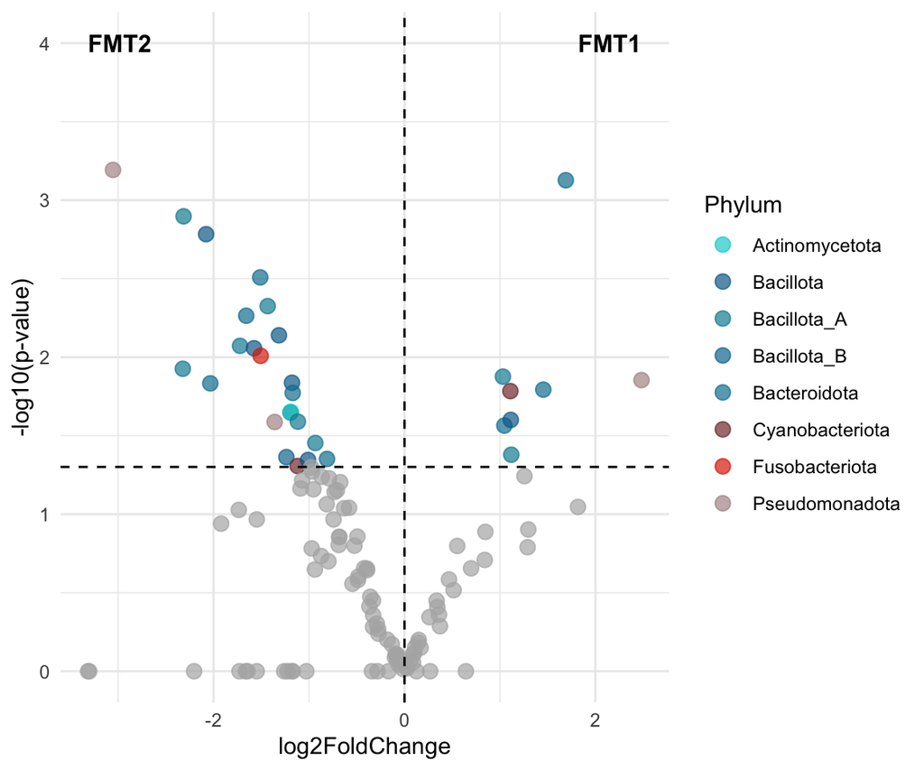

```r
ancombc_rand_table_mag %>%
  mutate(
    genome = factor(taxon, levels = ancombc_rand_table_mag$taxon),
    significance = ifelse(p_time_pointFMT2 < 0.05, phylum, NA)  # Set non-significant to NA (not mapped in legend)
  ) %>%
  ggplot() +
  # Plot significant points with legend
  geom_point(aes(x = lfc_time_pointFMT2, y = -log10(p_time_pointFMT2), color = significance),
             size = 3, alpha = 0.7, na.rm = TRUE) +
  # Plot non-significant points separately without legend
  geom_point(data = filter(ancombc_rand_table_mag, p_time_pointFMT2 >= 0.05),
             aes(x = lfc_time_pointFMT2, y = -log10(p_time_pointFMT2)),
             color = "grey70", size = 3, alpha = 0.7, show.legend = FALSE) +
  scale_color_manual(
    values = tax_color,  # Only keeps phylum colors in legend
    na.translate = FALSE  # Removes NA (non-significant) from legend
  ) +
  geom_hline(yintercept = -log10(0.05), linetype = "dashed") +
  geom_vline(xintercept = 0, linetype = "dashed") +
  scale_y_continuous(limits = c(0, 4)) +
  xlab("log2FoldChange") +
  ylab("-log10(p-value)") +
  guides(color = guide_legend(title = "Phylum")) +
  theme_minimal()+
  annotate("text", x = min(ancombc_rand_table_mag$lfc_time_pointFMT2), y = 4,
           label = "FMT2", hjust = 0, size = 4, fontface = "bold") +
  annotate("text", x = max(ancombc_rand_table_mag$lfc_time_pointFMT2), y = 4,
           label = "FMT1", hjust = 1, size = 4, fontface = "bold")
```

*Phyla of the significant MAGs in FMT1*

```r
ancombc_rand_table_mag%>%
  filter(p_time_pointFMT2 < 0.05) %>%
  filter(lfc_time_pointFMT2>0)  %>%
  count(phylum, name = "sample_count") %>%
  arrange(desc(sample_count))
```

```
           phylum sample_count
1    Bacteroidota            3
2     Bacillota_A            2
3       Bacillota            1
4 Cyanobacteriota            1
5  Pseudomonadota            1
```

*Phyla of the significant MAGs in FMT2*

```r
ancombc_rand_table_mag%>%
  filter(p_time_pointFMT2 < 0.05) %>%
  filter(lfc_time_pointFMT2<0)  %>%
  count(phylum, name = "sample_count") %>%
  arrange(desc(sample_count))
```

```
           phylum sample_count
1     Bacillota_A            6
2    Bacteroidota            6
3       Bacillota            5
4  Pseudomonadota            2
5  Actinomycetota            1
6     Bacillota_B            1
7 Cyanobacteriota            1
8  Fusobacteriota            1
```

#### 9.3.2.3 WC: FMT1 vs FMT2

*Structural zeros*

```r
struc <- structural_zeros %>%
  filter(present=="FMT1")%>%
  count(phylum, name = "FMT1") %>%
  arrange(desc(FMT1))
structural_zeros %>%
  filter(present=="FMT2")%>%
  count(phylum, name = "FMT2") %>%
  arrange(desc(FMT2)) %>%
  full_join(., struc, by="phylum") %>%
  mutate(across(everything(), ~ ifelse(is.na(.), 0, .))) %>%
  tt()
```

| phylum | FMT2 | FMT1 |
| --- | --- | --- |
| p__Bacillota_A | 12 | 13 |
| p__Bacteroidota | 8 | 3 |
| p__Bacillota | 4 | 5 |
| p__Pseudomonadota | 4 | 1 |
| p__Cyanobacteriota | 3 | 0 |
| p__Desulfobacterota | 2 | 0 |
| p__Verrucomicrobiota | 2 | 0 |
| p__Bacillota_B | 1 | 0 |
| p__Bacillota_C | 0 | 1 |

```r
phylo_samples <- sample_metadata %>%
  filter(type == "Hot_control" & time_point %in% c("FMT1", "FMT2") )%>%
  column_to_rownames("Tube_code") %>%
  sample_data()
phylo_genome <- genome_counts_filt %>%
  filter(!genome %in% structural_zeros$genome) %>%
  select(one_of(c("genome",rownames(phylo_samples)))) %>%
  filter(rowSums(across(where(is.numeric), ~ . != 0)) > 0) %>%
  select(genome, where(~ is.numeric(.) && sum(.) > 0)) %>%
  column_to_rownames("genome") %>%
  otu_table(., taxa_are_rows = TRUE)
phylo_taxonomy <- genome_metadata %>%
  filter(genome %in% rownames(phylo_genome)) %>%
  column_to_rownames("genome") %>%
  dplyr::select(domain,phylum,class,order,family,genus,species) %>%
  as.matrix() %>%
  tax_table()

physeq_genome_filtered <- phyloseq(phylo_genome, phylo_taxonomy, phylo_samples)
```

```r
ancom_rand_output_wc_fmt1_FMT2 = ancombc2(data = physeq_genome_filtered,
                  assay_name = "counts",
                  tax_level = NULL,
                  fix_formula = "time_point",
                  p_adj_method = "holm",
                  pseudo_sens = TRUE,
                  prv_cut =0,
                  lib_cut = 0,
                  s0_perc = 0.05,
                  group = NULL,
                  struc_zero = FALSE,
                  neg_lb = FALSE,
                  alpha = 0.05,
                  n_cl = 2,
                  verbose = TRUE,
                  global = FALSE,
                  pairwise = FALSE,
                  dunnet = FALSE,
                  trend = FALSE,
                  iter_control = list(tol = 1e-5, max_iter = 20, verbose = FALSE),
                  em_control = list(tol = 1e-5, max_iter = 100),
                  mdfdr_control = list(fwer_ctrl_method = "holm", B = 100),
                  trend_control = NULL)
```

```r
save(ancom_rand_output_wc_fmt1_FMT2, file="data/ancom_rand_output_wc_fmt1_FMT2.RData")
```

```r
load("data/ancom_rand_output_wc_fmt1_FMT2.RData")
```

```r
ancom_rand_output_wc_fmt1_FMT2$res %>%
  dplyr::select(taxon, lfc_time_pointFMT2, p_time_pointFMT2) %>%
  filter(p_time_pointFMT2 < 0.05) %>%
  left_join(., genome_metadata, by=join_by("taxon"=="genome")) %>%
  select(2,3,7,8,9) %>%
  tt()
```

| lfc_time_pointFMT2 | p_time_pointFMT2 | order | family | genus |
| --- | --- | --- | --- | --- |
| 1.2537326 | 0.029011592 | o__Gastranaerophilales | f__Gastranaerophilaceae | g__Limenecus |
| -1.2446217 | 0.020897423 | o__Fusobacteriales | f__Fusobacteriaceae | g__Fusobacterium_A |
| -1.3152585 | 0.044543566 | o__Campylobacterales | f__Helicobacteraceae | g__Helicobacter_J |
| -0.8821247 | 0.029330814 | o__Lachnospirales | f__Lachnospiraceae | g__UMGS1251 |
| 1.0370118 | 0.034798957 | o__Bacteroidales | f__Marinifilaceae | g__Odoribacter |
| -1.4081840 | 0.011345343 | o__Erysipelotrichales | f__Coprobacillaceae | g__Coprobacillus |
| -1.1775932 | 0.019499013 | o__Erysipelotrichales | f__Erysipelotrichaceae | g__ |
| 1.3523456 | 0.016477166 | o__Desulfovibrionales | f__Desulfovibrionaceae | g__Desulfovibrio |
| 1.3457840 | 0.022072104 | o__Christensenellales | f__UBA1242 | g__ |
| -1.7017766 | 0.009626806 | o__Bacteroidales | f__Tannerellaceae | g__Parabacteroides |
| 1.2803274 | 0.043789284 | o__Acidaminococcales | f__Acidaminococcaceae | g__Phascolarctobacterium |
| -1.3245580 | 0.011056772 | o__Bacteroidales | f__Tannerellaceae | g__Parabacteroides |
| 1.3062379 | 0.019865972 | o__Bacteroidales | f__Marinifilaceae | g__Odoribacter |
| 1.3245459 | 0.013082060 | o__UBA3830 | f__UBA3830 | g__ |
| -1.5592978 | 0.025407226 | o__Enterobacterales | f__Enterobacteriaceae | g__Proteus |
| -1.0812434 | 0.013919048 | o__Lachnospirales | f__Lachnospiraceae | g__Eisenbergiella |
| -1.0099993 | 0.023380581 | o__Bacteroidales | f__Bacteroidaceae | g__Bacteroides |
| -1.2817587 | 0.001367698 | o__Bacteroidales | f__Bacteroidaceae | g__Bacteroides |
| -1.1580559 | 0.033213589 | o__Chlamydiales | f__Chlamydiaceae | g__ |
| 0.6998666 | 0.026257060 | o__Christensenellales | f__MGBC116941 | g__MGBC116941 |
| 1.5483904 | 0.002502671 | o__Christensenellales | f__ | g__ |
| -0.9563076 | 0.039772633 | o__Oscillospirales | f__Ruminococcaceae | g__Anaerotruncus |
| 2.3773897 | 0.015636767 | o__Lachnospirales | f__Lachnospiraceae | g__14-2 |
| -0.9161289 | 0.047763620 | o__Bacteroidales | f__Rikenellaceae | g__Alistipes |
| -0.9044650 | 0.026634652 | o__Oscillospirales | f__Ruminococcaceae | g__Fournierella |
| 1.4541017 | 0.030212527 | o__Bacteroidales | f__Tannerellaceae | g__Parabacteroides_B |
| -1.0124183 | 0.011201440 | o__Lachnospirales | f__Lachnospiraceae | g__ |
| -0.9084866 | 0.028859682 | o__Bacteroidales | f__Bacteroidaceae | g__Bacteroides |
| -0.7064749 | 0.043580546 | o__Lachnospirales | f__Lachnospiraceae | g__Copromonas |
| -0.7714673 | 0.029067633 | o__Oscillospirales | f__Oscillospiraceae | g__Pseudoflavonifractor |
| 1.5835650 | 0.022738072 | o__Bacteroidales | f__Rikenellaceae | g__Alistipes |
| -1.8505816 | 0.008115738 | o__Christensenellales | f__UBA3700 | g__ |
| -1.1895270 | 0.015730599 | o__Bacteroidales | f__Bacteroidaceae | g__Bacteroides |
| -1.4689203 | 0.016641039 | o__RF32 | f__CAG-239 | g__CAJLXD01 |

```r
taxonomy <- data.frame(physeq_genome_filtered@tax_table) %>%
  rownames_to_column(., "taxon") %>%
  mutate_at(vars(order, phylum, family, genus, species), ~ str_replace(., "[dpcofgs]__", ""))

ancombc_rand_table_mag <- ancom_rand_output_wc_fmt1_FMT2$res %>%
  dplyr::select(taxon, lfc_time_pointFMT2, p_time_pointFMT2) %>%
  #filter(p_time_pointFMT2 < 0.05) %>%
  dplyr::arrange(p_time_pointFMT2) %>%
  merge(., taxonomy, by="taxon") %>%
  mutate_at(vars(phylum, species), ~ str_replace(., "[dpcofgs]__", ""))%>%
  dplyr::arrange(lfc_time_pointFMT2)

ancombc_rand_table_mag
```

```
                    taxon lfc_time_pointFMT2 p_time_pointFMT2      domain           phylum                  class               order               family                 genus                       species
1   AH1_2nd_20:bin_000073      -4.3031986605      1.000000000 d__Bacteria        Bacillota             c__Bacilli     Lactobacillales      Enterococcaceae          Enterococcus      Enterococcus sp002174455
2   AH1_2nd_10:bin_000097      -2.9177221045      0.054500707 d__Bacteria     Bacteroidota         c__Bacteroidia       Bacteroidales       Tannerellaceae       Parabacteroides
3    LI1_2nd_8:bin_000019      -1.8505816110      0.008115738 d__Bacteria      Bacillota_A          c__Clostridia  Christensenellales              UBA3700
4   AH1_2nd_20:bin_000087      -1.7017765913      0.009626806 d__Bacteria     Bacteroidota         c__Bacteroidia       Bacteroidales       Tannerellaceae       Parabacteroides      Parabacteroides gordonii
5    AH1_2nd_7:bin_000003      -1.5592977512      0.025407226 d__Bacteria   Pseudomonadota c__Gammaproteobacteria    Enterobacterales   Enterobacteriaceae               Proteus              Proteus cibarius
6   AH1_2nd_20:bin_000054      -1.5356764519      0.102478293 d__Bacteria        Bacillota             c__Bacilli  Erysipelotrichales  Erysipelotrichaceae                NSJ-61
7    LI1_2nd_9:bin_000007      -1.4689203139      0.016641039 d__Bacteria   Pseudomonadota c__Alphaproteobacteria                RF32              CAG-239              CAJLXD01
8    LI1_2nd_7:bin_000074      -1.4189758753      1.000000000 d__Bacteria   Pseudomonadota c__Gammaproteobacteria    Enterobacterales   Enterobacteriaceae           Escherichia              Escherichia coli
9   AH1_2nd_18:bin_000011      -1.4081840491      0.011345343 d__Bacteria        Bacillota             c__Bacilli  Erysipelotrichales     Coprobacillaceae         Coprobacillus
10   AH1_2nd_5:bin_000016      -1.3273361980      1.000000000 d__Bacteria        Bacillota             c__Bacilli     Lactobacillales      Enterococcaceae        Enterococcus_B         Enterococcus_B pernyi
11   AH1_2nd_5:bin_000073      -1.3245580375      0.011056772 d__Bacteria     Bacteroidota         c__Bacteroidia       Bacteroidales       Tannerellaceae       Parabacteroides   Parabacteroides goldsteinii
12  AH1_2nd_12:bin_000012      -1.3152585091      0.044543566 d__Bacteria Campylobacterota     c__Campylobacteria   Campylobacterales    Helicobacteraceae        Helicobacter_J
13   AH1_2nd_9:bin_000047      -1.2817586725      0.001367698 d__Bacteria     Bacteroidota         c__Bacteroidia       Bacteroidales       Bacteroidaceae           Bacteroides
14  AH1_2nd_11:bin_000028      -1.2753870314      0.062137762 d__Bacteria     Bacteroidota         c__Bacteroidia       Bacteroidales       Bacteroidaceae           Bacteroides
```

[output cut: 87 more lines]

```r
colors_alphabetic <- read_tsv("https://raw.githubusercontent.com/earthhologenome/EHI_taxonomy_colour/main/ehi_phylum_colors.tsv") %>%
  mutate_at(vars(phylum), ~ str_replace(., "[dpcofgs]__", ""))  %>%
  right_join(taxonomy, by=join_by(phylum == phylum)) %>%
  dplyr::select(phylum, colors) %>%
  mutate(colors = str_c(colors, "80"))  %>% #add 80% alpha
    unique() %>%
    dplyr::arrange(phylum)

tax_table <- as.data.frame(unique(ancombc_rand_table_mag$phylum))

colnames(tax_table)[1] <- "phylum"
tax_color <- merge(tax_table, colors_alphabetic, by="phylum")%>%
    dplyr::arrange(phylum) %>%
    dplyr::select(colors) %>%
    pull()
```

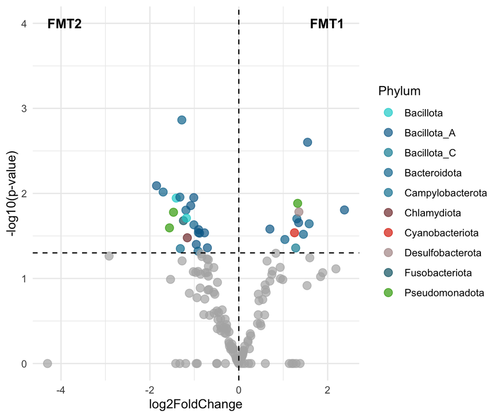

```r
ancombc_rand_table_mag %>%
  mutate(
    genome = factor(taxon, levels = ancombc_rand_table_mag$taxon),
    significance = ifelse(p_time_pointFMT2 < 0.05, phylum, NA)  # Set non-significant to NA (not mapped in legend)
  ) %>%
  ggplot() +
  # Plot significant points with legend
  geom_point(aes(x = lfc_time_pointFMT2, y = -log10(p_time_pointFMT2), color = significance),
             size = 3, alpha = 0.7, na.rm = TRUE) +
  # Plot non-significant points separately without legend
  geom_point(data = filter(ancombc_rand_table_mag, p_time_pointFMT2 >= 0.05),
             aes(x = lfc_time_pointFMT2, y = -log10(p_time_pointFMT2)),
             color = "grey70", size = 3, alpha = 0.7, show.legend = FALSE) +
  scale_color_manual(
    values = tax_color,  # Only keeps phylum colors in legend
    na.translate = FALSE  # Removes NA (non-significant) from legend
  ) +
  geom_hline(yintercept = -log10(0.05), linetype = "dashed") +
  geom_vline(xintercept = 0, linetype = "dashed") +
  scale_y_continuous(limits = c(0, 4)) +
  xlab("log2FoldChange") +
  ylab("-log10(p-value)") +
  guides(color = guide_legend(title = "Phylum")) +
  theme_minimal()+
  annotate("text", x = min(ancombc_rand_table_mag$lfc_time_pointFMT2), y = 4,
           label = "FMT2", hjust = 0, size = 4, fontface = "bold") +
  annotate("text", x = max(ancombc_rand_table_mag$lfc_time_pointFMT2), y = 4,
           label = "FMT1", hjust = 1, size = 4, fontface = "bold")
```

*Phyla of the significant MAGs in FMT1*

```r
ancombc_rand_table_mag%>%
  filter(p_time_pointFMT2 < 0.05) %>%
  filter(lfc_time_pointFMT2>0)  %>%
  count(phylum, name = "sample_count") %>%
  arrange(desc(sample_count))
```

```
            phylum sample_count
1      Bacillota_A            4
2     Bacteroidota            4
3      Bacillota_C            1
4  Cyanobacteriota            1
5 Desulfobacterota            1
6   Pseudomonadota            1
```

*Phyla of the significant MAGs in FMT2*

```r
ancombc_rand_table_mag%>%
  filter(p_time_pointFMT2 < 0.05) %>%
  filter(lfc_time_pointFMT2<0)  %>%
  count(phylum, name = "sample_count") %>%
  arrange(desc(sample_count))
```

```
            phylum sample_count
1      Bacillota_A            8
2     Bacteroidota            7
3        Bacillota            2
4   Pseudomonadota            2
5 Campylobacterota            1
6      Chlamydiota            1
7   Fusobacteriota            1
```